# zee_recommendation_V2

```python
from google.colab import drive
drive.mount('/content/drive')
```

```python
pip install BeautifulTable
```

```python
pip install cmfrec
```

**Problem Statement:**  
The primary goal is to develop a personalized movie recommendation system that enhances the user experience by suggesting movies based on the ratings provided by the user and those of other similar users. The recommendation system will leverage collaborative filtering techniques, including both item-based and user-based approaches, and matrix factorization methods to provide accurate and meaningful recommendations.

```python
import pandas as pd
import numpy as np
import matplotlib.pyplot as plt
import seaborn as sns
import math
from datetime import datetime,timedelta
import warnings
warnings.filterwarnings('ignore')
from collections import Counter
import time
import re
import pickle
from sklearn.preprocessing import StandardScaler, MinMaxScaler
from itertools import product


import pickle
from sklearn.preprocessing import StandardScaler, MinMaxScaler
from sklearn.impute import SimpleImputer
from sklearn.model_selection import train_test_split
from sklearn.model_selection import StratifiedKFold
from imblearn.over_sampling import SMOTE
from statsmodels.stats.outliers_influence import variance_inflation_factor
from sklearn.linear_model import LogisticRegression
from itertools import product
from sklearn.impute import KNNImputer
from sklearn.metrics import mean_squared_error,mean_absolute_percentage_error
from sklearn.metrics import roc_auc_score,roc_curve,auc, precision_score, recall_score, precision_recall_curve,fbeta_score
from mlxtend.plotting import plot_confusion_matrix

from copy import deepcopy
from beautifultable import BeautifulTable
pd.set_option('display.max_rows', 500)
pd.set_option('display.max_columns', 500)
```

```python
#pathh=r'/content/drive/MyDrive/Colab Notebooks/Recommendation_zee/ZEE-data'
pathh=r'ZEE-data'
movies_data=pd.read_csv(pathh+'/zee-movies.dat',delimiter='::', encoding='ISO-8859-1')
ratings_data=pd.read_csv(pathh+'/zee-ratings.dat',delimiter='::')
users_data=pd.read_csv(pathh+'/zee-users.dat',delimiter='::')
```

```python
##Variables with missing values
def check_missing_values(data):
    null_cols=data.isna().sum(axis=0).reset_index()
    null_cols.columns=['columns','null_counts']
    null_cols=null_cols.loc[null_cols.null_counts>0].sort_values('null_counts',ascending=False)

    null_cols['null_percent']=100*null_cols['null_counts']/len(data)
    null_cols.reset_index(drop=True,inplace=True)
    return null_cols


check_missing_values(users_data)
##no nulls in movies, users and ratings data
```

|  | columns | null_counts | null_percent |
| --- | --- | --- | --- |

```python
movies_data['release_date']=movies_data.Title.apply(lambda x:re.findall(r'\(([\d]+)\)',str(x))[0]).astype(int)
genres=movies_data.Genres.apply(lambda x:x.split('|')).explode().reset_index()
genres=genres.groupby(['index','Genres']).Genres.count().unstack().fillna(0)

movies_data=movies_data.merge(genres,how='left',left_index=True,right_index=True)
```

```python
ratings_data.loc[:,'Timestamp']=ratings_data.Timestamp.apply(lambda x:datetime.fromtimestamp(x))
ratings_data['rated_year']=ratings_data.Timestamp.dt.year
ratings_data['rated_weeknum']=ratings_data.Timestamp.dt.isocalendar().week.astype(int)

ratings_data=ratings_data.merge(users_data,how='left',on='UserID')
ratings_data=ratings_data.merge(movies_data,how='left',left_on='MovieID',right_on='Movie ID')
ratings_data['yrs_bet_release_and_rated']=ratings_data.rated_year-ratings_data.release_date

ratings_data.rename({"Children's":"Children"
                    ,'Film-Noir':'Film_Noir'
                    ,'Sci-Fi':'Sci_Fi'},axis=1,inplace=True)
```

```python
check_missing_values(ratings_data)
#no missing values in ratings dataset
```

|  | columns | null_counts | null_percent |
| --- | --- | --- | --- |

```python
#ratings_data['Zip-code'].value_counts()
##dropping zip-code.. too many cardinality
```

```python
ratings_data.drop(['Zip-code','Movie ID'],axis=1,inplace=True)
```

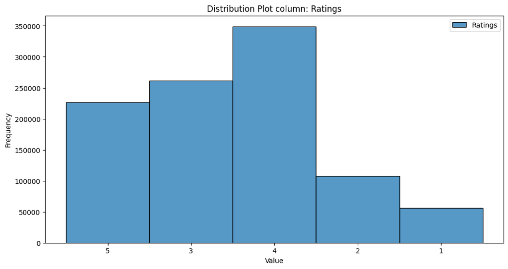

```python
plt.figure(figsize=(12, 6))

sns.histplot(ratings_data.Rating.astype(str), label='{}'.format('Ratings'), palette='viridis')

plt.title('Distribution Plot column: {}'.format('Ratings'))
plt.xlabel('Value')
plt.ylabel('Frequency')
plt.legend()

# Show plot
plt.show()
```

```python
ratings_data.rated_weeknum.value_counts(normalize=True)[:5]
```

```
47    0.171741
31    0.082202
46    0.055076
48    0.051339
49    0.047162
Name: rated_weeknum, dtype: float64
```

```python
r=ratings_data.groupby(['Age']).apply(lambda x:x[['Action', 'Adventure', 'Animation', 'Children',
       'Comedy', 'Crime', 'Documentary', 'Drama', 'Fantasy', 'Film_Noir',
       'Horror', 'Musical', 'Mystery', 'Romance', 'Sci_Fi', 'Thriller', 'War',
       'Western']].sum(axis=0))

r['dist']=''
for idx,row in r.iterrows():
    k=(100*r.loc[idx,r.columns[:-1]]/r.loc[idx,r.columns[:-1]].sum()).sort_values(ascending=False).reset_index()
    r.loc[idx,'dist']=','.join(k.iloc[:5,0]+'('+k.iloc[:5,1].astype(float).round(0).astype(str)+'%)')

r['dist']
```

```
Age
1     Comedy(19.0%),Drama(13.0%),Action(11.0%),Thril...
18    Comedy(18.0%),Drama(15.0%),Action(13.0%),Thril...
25    Comedy(17.0%),Drama(17.0%),Action(13.0%),Thril...
35    Drama(17.0%),Comedy(17.0%),Action(12.0%),Thril...
45    Drama(19.0%),Comedy(16.0%),Action(11.0%),Thril...
50    Drama(20.0%),Comedy(15.0%),Action(11.0%),Thril...
56    Drama(22.0%),Comedy(15.0%),Action(10.0%),Thril...
Name: dist, dtype: object
```

```python
ratings_data.loc[:,'Title']=ratings_data['Title'].apply(lambda x:re.sub(r"[']",'',str(x).lower()))
```

### Hypothesis test and Distribution of variables across different ratings

```
=============== Gender-Rating ================



Gender      F       M
Rating
1       13347   42827
2       24548   83009
3       62966  198231
4       87033  261938
5       58546  167764
chi2: 455.86073811141705 with p_value: 2.3485611329249177e-97
There is a statistically significant association between Gender and Rating.
```

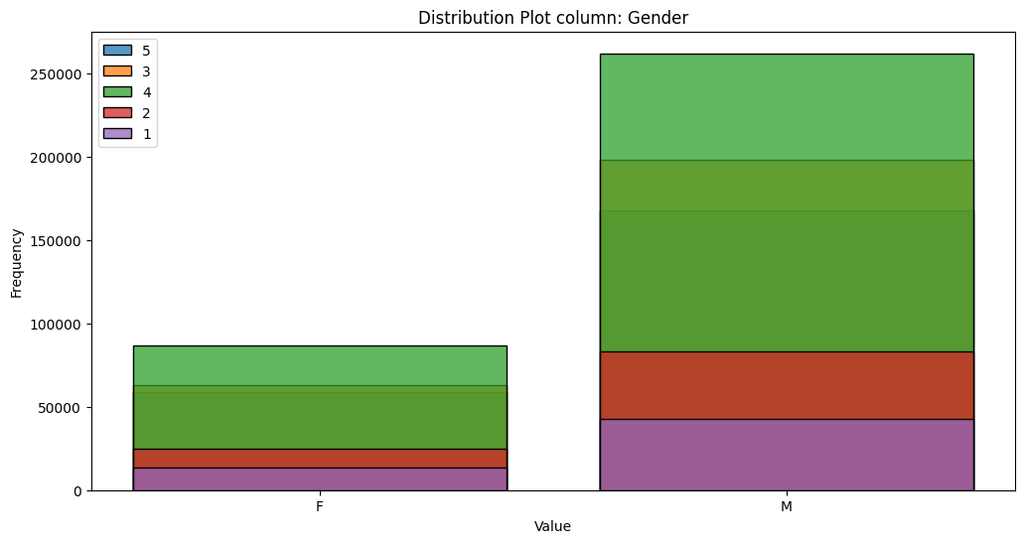

```
=============== Age-Rating ================



Age       1      18      25     35     45     50     56
Rating
1       2238  13063   23898   9067   3409   2948   1551
2       2983  22073   44817  20253   8437   5993   3001
3       6380  47601  104287  52990  22311  18465   9163
4       8808  60241  136824  71983  30334  26484  14297
5       6802  40558   85730  44710  19142  18600  10768
chi2: 5419.9415710815465 with p_value: 0.0
There is a statistically significant association between Age and Rating.
```

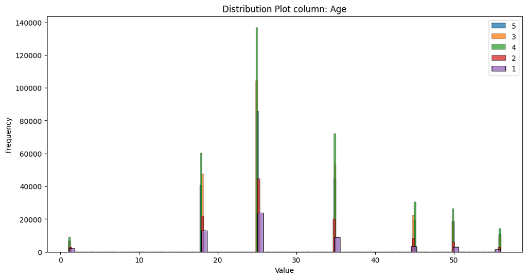

```
=============== Occupation-Rating ================



Occupation     0      1      2      3      4     5      6      7    8     9   \
Rating
1            7892   4756   3062   1521   9004  1070   2046   5076  176   393
2           14679   9054   5486   3083  15418  2552   3332  10978  292  1045
3           35494  22361  12919   7958  33119  6446   9058  28054  820  3182
4           44256  30577  16899  11236  43219  7127  13500  38273  929  4170
5           28178  18603  11702   7825  30272  4655   9269  23044  489  2555

Occupation    10    11     12    13     14    15     16     17    18    19  \
Rating
1           2058  1337   2578   405   2345   887   2051   3351   583  1417
2           2570  2056   5675  1176   5160  2271   4980   7193  1295  1835
3           5392  4814  14382  3274  12696  5571  12355  19908  3655  3991
4           7448  7287  20909  5060  17593  8568  16733  26155  4238  4482
5           5822  5069  13670  3839  11315  5654   9902  16209  2315  3179

Occupation     20
Rating
1            4166
2            7427
3           15748
4           20312
5           12744
chi2: 5370.499189940039 with p_value: 0.0
There is a statistically significant association between Occupation and Rating.
```

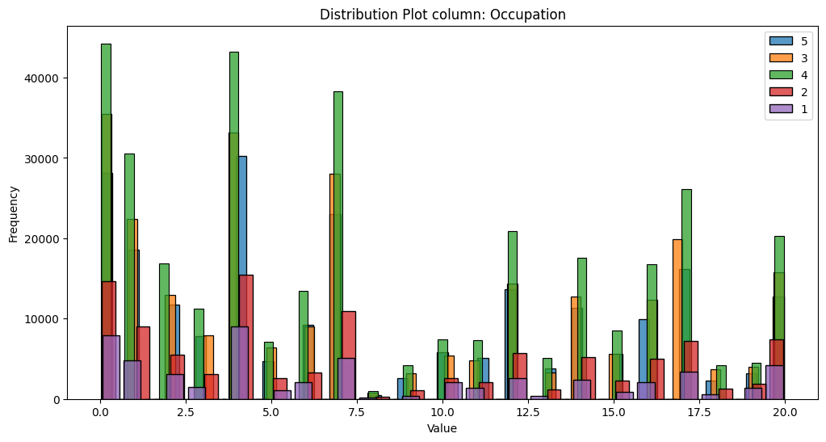

```
=============== rated_year-Rating ================



rated_year    2000   2001  2002  2003
Rating
1            51017   3549  1354   254
2            96021   8032  3114   390
3           234132  19311  6900   854
4           314230  25052  8502  1187
5           208775  12684  4183   668
chi2: 1383.5851308494402 with p_value: 4.81005603077088e-289
There is a statistically significant association between rated_year and Rating.
```

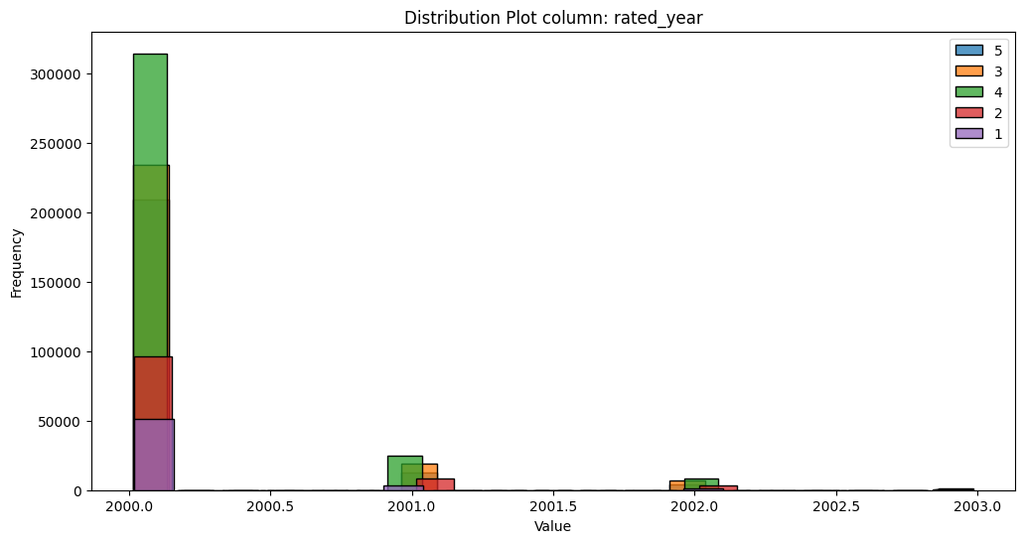

```
=============== release_date-Rating ================



release_date  1919  1920  1921  1922  1923  1925  1926  1927  1928  1929  \
Rating
1                3     2     3    12     4    23    14     7     2     6
2                3     3     5    10     2    15    24     5     0     5
3               15     4    10    42     2    99    98    31     4    13
4               18     7    28    78     6   203   165    77    14    14
5                6     8    16    96     3   221   171   132     7     5

release_date  1930  1931  1932  1933  1934  1935  1936  1937  1938  1939  \
Rating
1               11    30    18    38    22    17    13    44    26    77
2               13    52    29   109    28    26    27    71    40   150
3               60   205   101   380   180   167   114   325   223   690
4              148   463   140   581   426   421   241   542   515  1262
5              150   523    84   497   388   314   233   437   473  1605

release_date  1940  1941  1942  1943  1944  1945  1946  1947  1948  1949  \
Rating
1              102    49    67    28    46    24    44    21    35    23
2              222   118   127    46    72    59    79    52    56    45
3              890   555   605   148   446   251   385   244   357   185
4             1628  1163  1111   237   990   370   938   395   706   347
5             1589  1557  1403   165   922   227  1087   273   627   385

release_date  1950  1951  1952  1953  1954  1955  1956  1957  1958  1959  \
Rating
1               43    51    23    77    91    67    98    82   224   117
2              120   144    67   176   227   185   189   126   342   225
3              530   696   270   741   868   844   636   537  1153   898
4              984  1507   562  1277  1664  1496  1157  1207  1798  1767
5              913  1471   675   901  1807   919   785  1400  1293  1802

release_date  1960  1961  1962  1963  1964  1965  1966  1967  1968  1969  \
Rating
1               81   118   104   153    96   117    40    77   266    80
2              201   342   196   308   232   292   111   259   580   260
```

[output cut: 22 more lines]

```
1              1951  1247   2331   2557   3452   4078   4540   4738   4709
2              3868  2588   4721   5142   6568   7684   8001   8533   8525
3              8854  6661  11087  12528  14594  16880  16852  18563  18751
4             10186  8832  13246  16391  17439  20158  19827  22204  23310
5              5458  5455   6481   9699  10910  11954  10162  11364  12931

release_date   1999   2000
Rating
1              6386   3551
2             10704   5313
3             22158  11125
4             28585  14300
5             19000   6711
chi2: 34816.68943592907 with p_value: 0.0
There is a statistically significant association between release_date and Rating.
```

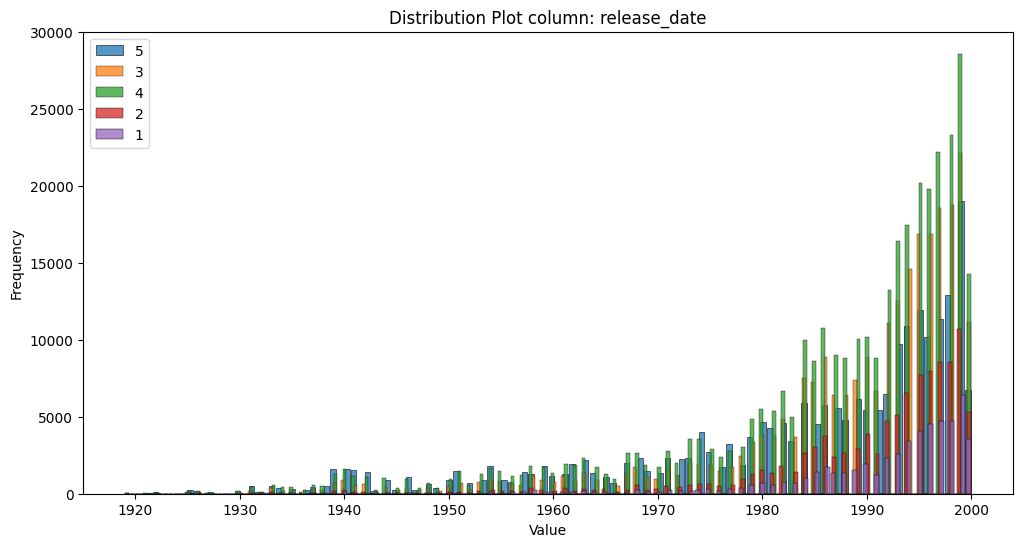

```
=============== rated_weeknum-Rating ================



rated_weeknum    1     2     3     4     5    6    7     8    9    10   11  \
Rating
1               272   197   219   317   306  110  203   125   82  139  116
2               855   562   535   579   485  221  410   362  342  266  244
3              2184  1570  1202  1292  1132  591  776   922  747  633  450
4              2810  2040  1577  1673  1414  983  878  1362  935  736  519
5              1473  1058   899   906   709  585  444   794  457  349  261

rated_weeknum   12   13   14   15   16    17    18    19    20    21    22  \
Rating
1               68   74  264   87   85   574   871  1254  1024   956   922
2              208  140  341  216  158  1418  1555  1790  1725  1664  2072
3              602  371  816  439  330  3620  3692  4583  3718  4338  4989
4              812  388  945  608  450  4407  4775  6826  5330  5566  7464
5              350  183  390  329  250  2743  3494  4484  3639  4120  5028

rated_weeknum    23    24    25    26     27    28    29    30     31     32  \
Rating
1               864   776   584   954   1724   652   812   661   4849   2468
2              1483  1450  1238  1958   3598  1401  1527  1090   9131   5239
3              3422  3368  2896  4584  10351  4195  3661  2822  22540  11659
4              4795  5173  4184  6224  14557  5233  4814  4141  28076  14718
5              2915  3134  2681  4736   9420  3366  2878  2400  17623   9934

rated_weeknum     33    34    35    36    37    38    39    40    41    42  \
Rating
1               2113  1301  1259   973   873   463   344   522   312   421
2               3493  2411  2441  1942  1316   999   829   916   864   981
3               9201  6479  5392  4437  3045  3087  2406  2556  2301  2518
4              11647  8871  7195  6147  4128  4000  3593  3683  2996  3251
5               7459  6368  4895  4025  2987  2441  2654  2016  2018  2302

rated_weeknum    43    44    45     46     47     48     49    50    51    52
Rating
1               686   969   714   2586  11199   3134   2385  1493   905   913
2              1595  1703  1563   5542  19617   5792   5227  2978  1620  1465
3              3590  4705  4402  14118  43824  14011  12063  6341  4211  4015
4              4328  6837  6312  19558  58373  17859  16526  8210  6002  5042
5              2591  4508  3750  13284  38764  10554  10971  5457  4036  3198
chi2: 4365.491665874443 with p_value: 0.0
There is a statistically significant association between rated_weeknum and Rating.
```

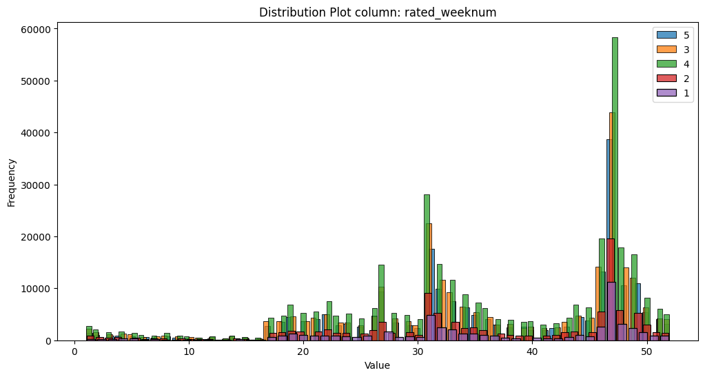

```
=============== Action-Rating ================



Action     0.0    1.0
Rating
1        39643  16531
2        76125  31432
3       190469  70728
4       262392  86579
5       174123  52187
chi2: 2335.7483013476444 with p_value: 0.0
There is a statistically significant association between Action and Rating.
```

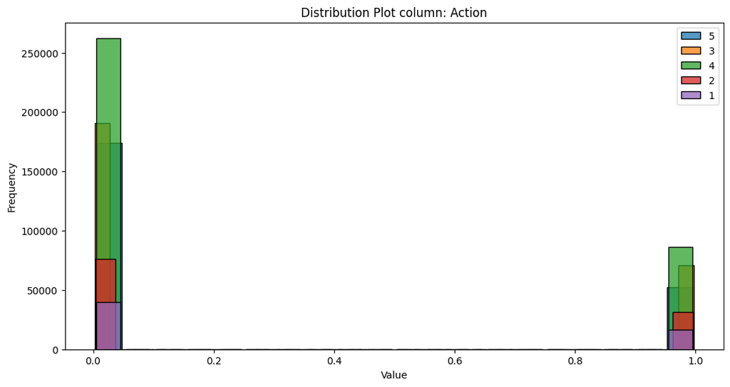

```
=============== Adventure-Rating ================



Adventure     0.0    1.0
Rating
1           47680   8494
2           90916  16641
3          223330  37867
4          304628  44343
5          199702  26608
chi2: 1483.710505057853 with p_value: 0.0
There is a statistically significant association between Adventure and Rating.
```

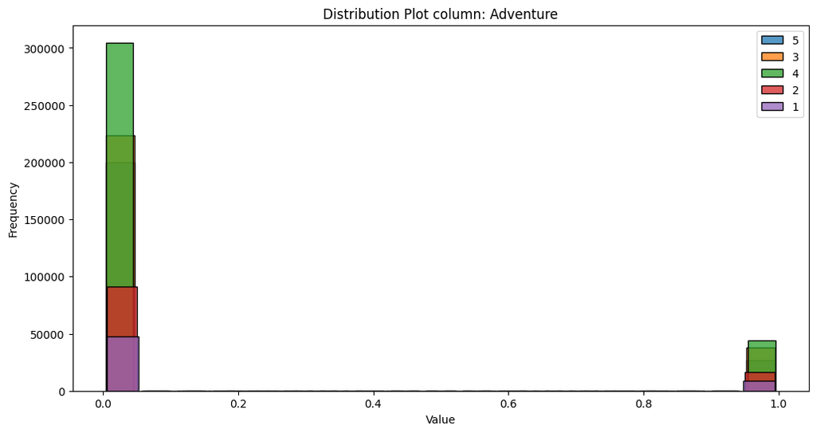

```
=============== Animation-Rating ================



Animation     0.0    1.0
Rating
1           54077   2097
2          103970   3587
3          250224  10973
4          333130  15841
5          215515  10795
chi2: 458.717410167822 with p_value: 5.6648006882804945e-98
There is a statistically significant association between Animation and Rating.
```

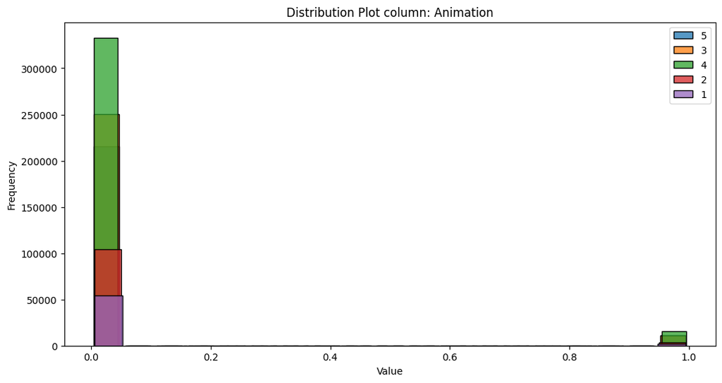

```
=============== Children-Rating ================



Children     0.0    1.0
Rating
1          50299   5875
2          98920   8637
3         240801  20396
4         325267  23704
5         212736  13574
chi2: 1720.3724808969591 with p_value: 0.0
There is a statistically significant association between Children and Rating.
```

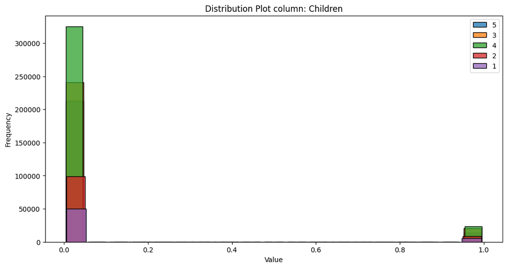

```
=============== Comedy-Rating ================



Comedy     0.0     1.0
Rating
1        34558   21616
2        66484   41073
3       164251   96946
4       225556  123415
5       152780   73530
chi2: 1739.562594245329 with p_value: 0.0
There is a statistically significant association between Comedy and Rating.
```

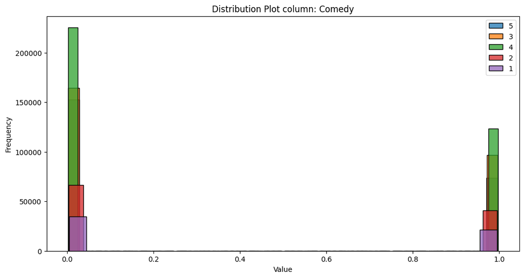

```
=============== Crime-Rating ================



Crime      0.0    1.0
Rating
1        52955   3219
2       100124   7433
3       241655  19542
4       320517  28454
5       205417  20893
chi2: 1142.9251440066153 with p_value: 3.7558259838917927e-246
There is a statistically significant association between Crime and Rating.
```

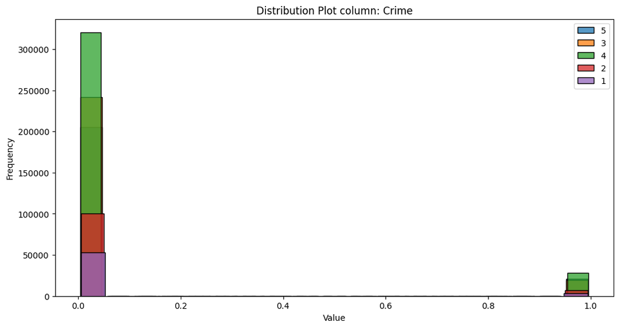

```
=============== Documentary-Rating ================



Documentary     0.0   1.0
Rating
1             55903   271
2            107080   477
3            259751  1446
4            345939  3032
5            223626  2684
chi2: 898.3084979138507 with p_value: 3.873909835368012e-193
There is a statistically significant association between Documentary and Rating.
```

[13 more figures not shown]

```python
from scipy import stats
import statsmodels.api as sm
import statsmodels.formula.api as smf

target_var='Rating'
categorical_vars=['Gender','Age','Occupation','rated_year'
                  ,'release_date','rated_weeknum','Action','Adventure','Animation','Children'
                  ,'Comedy','Crime','Documentary','Drama','Fantasy','Film_Noir','Horror'
                  ,'Musical','Mystery','Romance','Sci_Fi','Thriller','War','Western']
numerical_vars=['yrs_bet_release_and_rated']

def anova_lm_test(data, col, tar):
    # Perform ANOVA (Analysis of Variance)
    formula = f'{col} ~ C({tar})'
    model = smf.ols(formula, data=data).fit()
    anova_table = sm.stats.anova_lm(model, typ=2)

    print(anova_table)

    p_value = anova_table["PR(>F)"][0]
    ff=anova_table["F"][0]
    if p_value < 0.05:
        print(f'There is a statistically significant difference between the mean {col} across the groups in {tar}.')
        return ff,1
    else:
        print('There is no sufficient evidence of a significant difference between the means across the groups.')
        return ff,0


def cat_chi2test(data,col,tar):

    contingency_table=pd.crosstab(data[tar],data[col])
    print(contingency_table)

    chi2,p,dof,expected=stats.chi2_contingency(contingency_table)
    print('chi2: {} with p_value: {}'.format(chi2,p))
    if p<0.05:
        print('There is a statistically significant association between {} and {}.'.format(col,tar))
        return chi2,1
    else:
        print('There is no sufficient evidence of a significant association between {} and {}.'.format(col,tar))
        return chi2,0

def dist_cat_plot(d1,cols,tar):
    for col in cols:
        plt.figure(figsize=(12, 6))

        for label in d1[tar].unique():

            sns.histplot(d1.loc[d1[tar]==label,col], label='{}'.format(label), palette='viridis', multiple='dodge', shrink=0.8)

        plt.title('Distribution Plot column: {}'.format(col))
        plt.xlabel('Value')
        plt.ylabel('Frequency')
        plt.legend()

        # Show plot
        plt.show()

def dist_plot(d1,cols,tar):
    for col in cols:
        plt.figure(figsize=(12, 6))

        for label in d1[tar].unique():
            sns.kdeplot(d1.loc[d1[tar]==label,col], label='{}'.format(label), palette='viridis')  #kde=True,

        plt.title('Distribution Plot column: {}'.format(col))
        plt.xlabel('Value')
        plt.ylabel('Frequency')
        plt.legend()

        # Show plot
        plt.show()

for col in range(len(categorical_vars)):

    print('=============== {}-{} ================\n'.format(categorical_vars[col],target_var))
    print('\n')
    _,f=cat_chi2test(ratings_data,categorical_vars[col],target_var)
    dist_cat_plot(ratings_data,[categorical_vars[col]],target_var)

for col in numerical_vars:
    print('=============== {}-{} ================\n'.format(col,target_var),ratings_data.groupby([target_var])[col].describe())
    print('\n')
    _,f=anova_lm_test(ratings_data,col,target_var)
    dist_plot(ratings_data,[col],target_var)
```

```python
s=ratings_data[['Action','Adventure','Animation','Children'
                  ,'Comedy','Crime','Documentary','Drama','Fantasy','Film_Noir','Horror'
                  ,'Musical','Mystery','Romance','Sci_Fi','Thriller','War','Western']].sum(axis=0).sort_values(ascending=False)
s=s/s.sum()
s
```

```
Comedy         0.169653
Drama          0.168678
Action         0.122493
Thriller       0.090246
Sci_Fi         0.074837
Romance        0.070188
Adventure      0.063732
Crime          0.037844
Horror         0.036343
Children       0.034345
War            0.032604
Animation      0.020598
Musical        0.019761
Mystery        0.019116
Fantasy        0.017271
Western        0.009841
Film_Noir      0.008688
Documentary    0.003763
dtype: float64
```

### Correlations among Non-Target variables

```python
chi2_df=pd.DataFrame([[0]*len(categorical_vars)]*len(categorical_vars),index=categorical_vars,columns=categorical_vars)

for col in range(len(categorical_vars)):
    for col1 in range(col+1,len(categorical_vars)):

        print('=============== {}-{} ================\n'.format(categorical_vars[col],categorical_vars[col1]))
        print('\n')
        chi2_df.loc[categorical_vars[col],categorical_vars[col1]],f=cat_chi2test(ratings_data,categorical_vars[col],categorical_vars[col1])
```

```
=============== Gender-Age ================



Gender      F       M
Age
1        8827   18384
18      45427  138109
25      91340  304216
35      49473  149530
45      24110   59523
50      18064   54426
56       9199   29581
chi2: 2219.3928284660165 with p_value: 0.0
There is a statistically significant association between Gender and Age.
=============== Gender-Occupation ================



Gender          F      M
Occupation
0           32945  97554
1           32533  52818
2           16050  34018
3           14325  17298
4           32464  98568
5            3905  17945
6           14979  22226
7           17967  87458
8             636   2070
9           10554    791
10           6983  16307
11           2643  17920
12           6804  50410
13           2799  10955
14          11989  37120
15           4198  18753
16           7439  38582
17           7649  65167
18            414  11672
```

[output cut: 5318 more lines]

```
Western
0.0       790482  189044
1.0        20047     636
chi2: 3468.512772143891 with p_value: 0.0
There is a statistically significant association between Thriller and Western.
=============== War-Western ================



War         0.0    1.0
Western
0.0      911704  67822
1.0       19978    705
chi2: 391.67105976925467 with p_value: 3.5816858887768212e-87
There is a statistically significant association between War and Western.
```

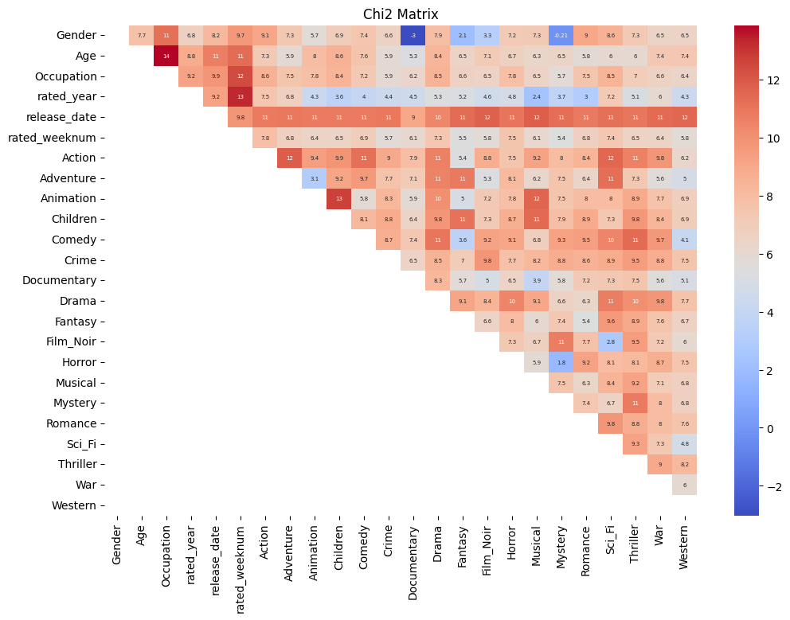

```python
mask = np.tril(np.ones_like(chi2_df, dtype=bool))
plt.figure(figsize=(12,8))
sns.heatmap(np.log(chi2_df),mask=mask,annot=True,cmap='coolwarm',annot_kws={'size':5})
plt.title('Chi2 Matrix')
plt.show()

##Animation and Children movies are highly correlated
##Action, Adventure and Sci-Fi are also observed to be correlated
```

```python
anova_df=pd.DataFrame([[0]*len(numerical_vars)]*len(categorical_vars),index=categorical_vars,columns=numerical_vars)

for col in numerical_vars:
    for col1 in range(len(categorical_vars)):
        print('=============== {}-{} ================\n'.format(col,categorical_vars[col1]),ratings_data.groupby([categorical_vars[col1]])[col].describe())
        print('\n')
        anova_df.loc[categorical_vars[col1],col],f=anova_lm_test(ratings_data,col,categorical_vars[col1])
```

```
=============== yrs_bet_release_and_rated-Gender ================
            count       mean        std  min  25%  50%   75%   max
Gender
F       246440.0  13.377305  14.903160  0.0  3.0  8.0  17.0  82.0
M       753769.0  13.445051  14.161373  0.0  3.0  8.0  18.0  82.0


                 sum_sq         df         F    PR(>F)
C(Gender)  8.523821e+02        1.0  4.140661  0.041865
Residual   2.058991e+08  1000207.0       NaN       NaN
There is a statistically significant difference between the mean yrs_bet_release_and_rated across the groups in Gender.
=============== yrs_bet_release_and_rated-Age ================
         count       mean        std  min  25%   50%   75%   max
Age
1     27211.0  11.264783  14.281971  0.0  2.0   5.0  14.0  80.0
18   183536.0  10.457687  12.355308  0.0  3.0   6.0  13.0  81.0
25   395556.0  12.159009  12.948707  0.0  3.0   8.0  16.0  82.0
35   199003.0  15.134475  15.060132  0.0  4.0  10.0  20.0  82.0
45    83633.0  16.592410  16.338052  0.0  4.0  11.0  24.0  82.0
50    72490.0  17.626321  16.739303  0.0  5.0  12.0  27.0  81.0
56    38780.0  18.527540  17.702525  0.0  4.0  12.0  29.0  81.0


                sum_sq         df            F  PR(>F)
C(Age)    6.086761e+06        6.0  5078.067233     0.0
Residual  1.998132e+08  1000202.0          NaN     NaN
There is a statistically significant difference between the mean yrs_bet_release_and_rated across the groups in Age.
=============== yrs_bet_release_and_rated-Occupation ================
                count       mean        std  min  25%   50%   75%   max
Occupation
0           130499.0  13.333941  14.215114  0.0  4.0   8.0  17.0  81.0
1            85351.0  14.777730  15.419532  0.0  4.0   9.0  20.0  82.0
2            50068.0  13.903052  14.690008  0.0  4.0   8.0  18.0  81.0
3            31623.0  14.505455  15.442765  0.0  4.0   8.0  19.0  81.0
4           131032.0  11.009708  12.891803  0.0  3.0   6.0  14.0  81.0
5            21850.0  13.317483  13.529653  0.0  4.0   9.0  18.0  81.0
6            37205.0  14.020185  14.785647  0.0  4.0   9.0  19.0  81.0
7           105425.0  14.085160  14.221950  0.0  4.0  10.0  19.0  82.0
8             2706.0  13.462676  13.147686  0.0  4.0  11.0  17.0  78.0
9            11345.0  13.599383  14.606330  0.0  4.0   8.0  17.0  81.0
```

[output cut: 364 more lines]

```
                sum_sq         df             F  PR(>F)
C(War)    2.510939e+06        1.0  12348.055234     0.0
Residual  2.033891e+08  1000207.0           NaN     NaN
There is a statistically significant difference between the mean yrs_bet_release_and_rated across the groups in War.
=============== yrs_bet_release_and_rated-Western ================
             count       mean        std  min  25%   50%   75%   max
Western
0.0      979526.0  13.275623  14.322357  0.0  3.0   8.0  17.0  82.0
1.0       20683.0  20.661800  13.670443  1.0  8.0  24.0  31.0  71.0


                  sum_sq         df            F  PR(>F)
C(Western)  1.105040e+06        1.0  5396.954273     0.0
Residual    2.047950e+08  1000207.0          NaN     NaN
There is a statistically significant difference between the mean yrs_bet_release_and_rated across the groups in Western.
```

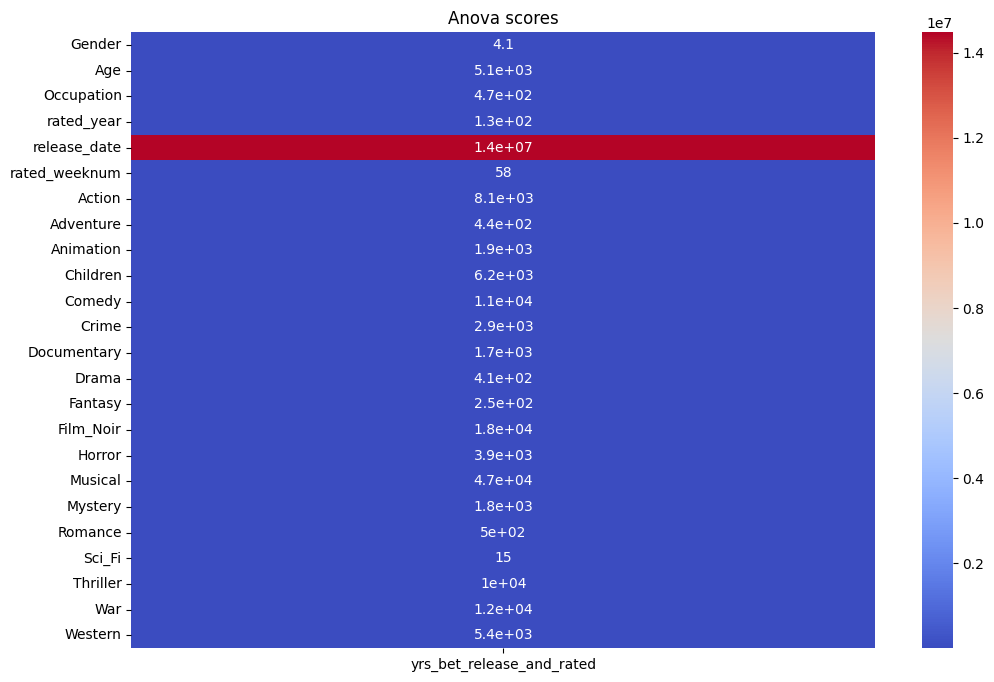

```python
plt.figure(figsize=(12,8))
sns.heatmap(anova_df,annot=True,cmap='coolwarm',annot_kws={'size':10})
plt.title('Anova scores')
plt.show()

#dropping occupation in supervised learning algo, as it has high correlation with age and lot of other categorical features
#dropping release_date
```

#### Checking how the rating on a movie changes across years

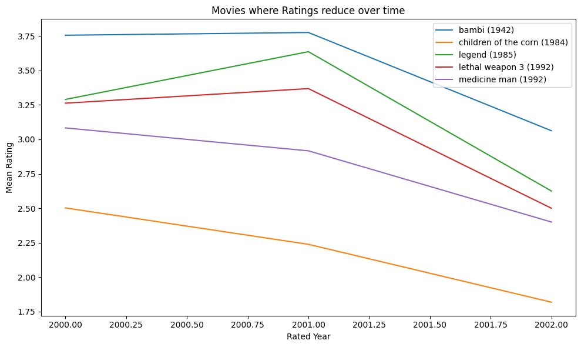

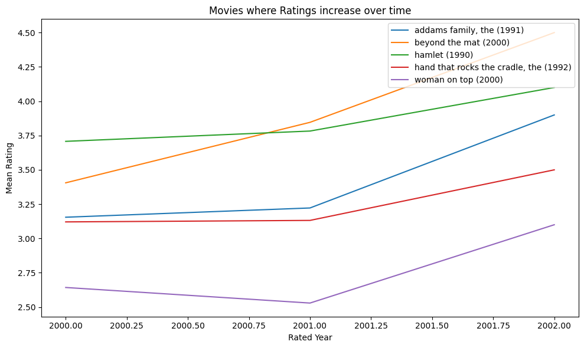

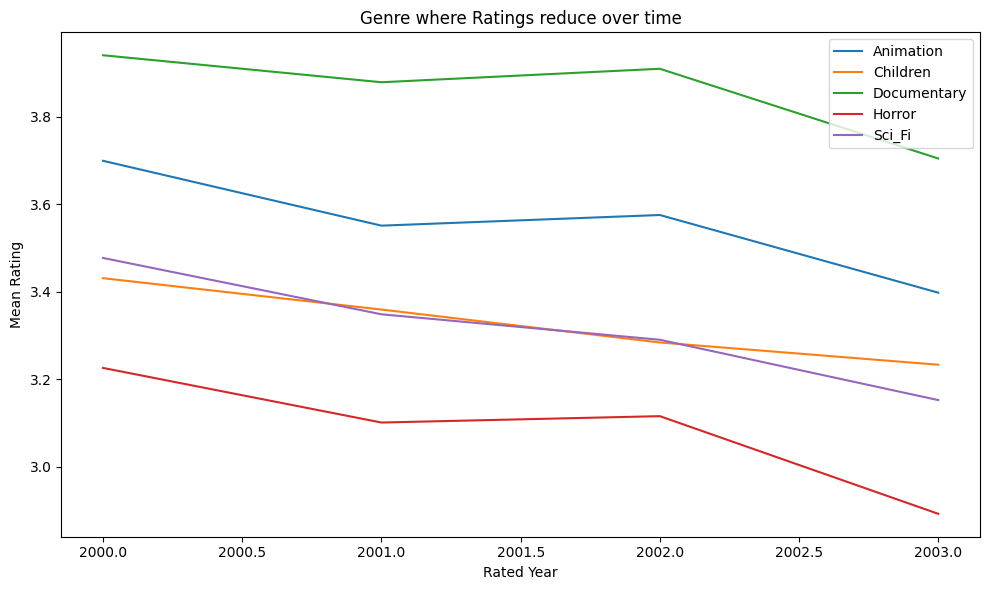

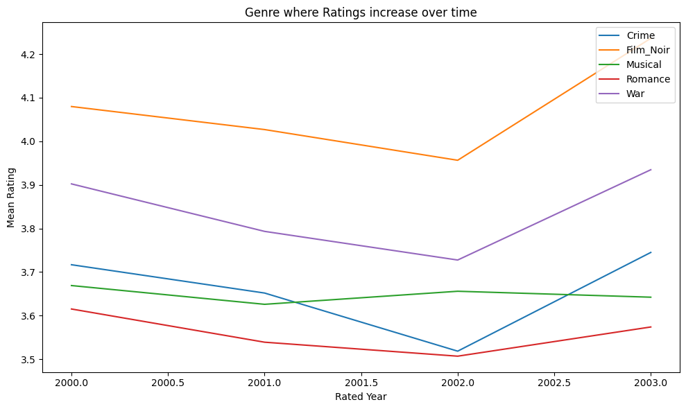

```python
count_years=3
volume_min=10

r_y_df=ratings_data.groupby(['Title','rated_year']).agg(mean_rating=('Rating','mean'),volume=('Rating','count'))
mm=pd.DataFrame()
for col in ['Action', 'Adventure', 'Animation', 'Children',
       'Comedy', 'Crime', 'Documentary', 'Drama', 'Fantasy', 'Film_Noir',
       'Horror', 'Musical', 'Mystery', 'Romance', 'Sci_Fi', 'Thriller', 'War',
       'Western']:
    m=ratings_data.loc[ratings_data[col]==1].groupby([col,'rated_year']).\
    agg(mean_rating=('Rating','mean'),volume=('Rating','count')).reset_index()
    m.loc[:,m.columns[0]]=m.columns[0]
    m.rename({m.columns[0]:'Title'},axis=1,inplace=True)
    mm=pd.concat([mm,m],axis=0,ignore_index=True)

mm.set_index(['Title','rated_year'],inplace=True)


def plot_ts(r_y_df,decrease_rates,tit):
    dd=r_y_df.loc[r_y_df.Title.isin(decrease_rates)]
    plt.figure(figsize=(10, 6))

    for title in dd.Title.unique():
        d=dd.loc[dd.Title==title]
        plt.plot(d.rated_year.astype(int), d.mean_rating, label=title)


    plt.xlabel('Rated Year')
    plt.ylabel('Mean Rating')
    plt.title(tit)
    plt.legend(loc='upper right')
    #plt.xticks(rotation=90)
    plt.tight_layout()
    #plt.xlim(max_null_data_t.index.min(),max_null_data_t.index.max())
    plt.show()

def TS_check(r_y_df,tit):
    r_y_df['diff_c']=r_y_df.groupby(['Title']).mean_rating.diff(1)
    r_y_df['c']=r_y_df.groupby(['Title']).mean_rating.transform('count')
    r_y_df['v_mean']=r_y_df.groupby(['Title']).volume.transform('min')
    r_y_df=r_y_df.loc[(r_y_df.c>=count_years)&(r_y_df.v_mean>=volume_min)].copy()
    r_y_df.reset_index(inplace=True)

    check_df=r_y_df.groupby(['Title'])['diff_c'].apply(lambda x: x.dropna().mean()).dropna().sort_values(ascending=True)
    decrease_rates=check_df[:5].index
    increase_rates=check_df[-5:].index
    plot_ts(r_y_df,decrease_rates,f'{tit} where Ratings reduce over time')

    plot_ts(r_y_df,increase_rates,f'{tit} where Ratings increase over time')


TS_check(r_y_df,'Movies')

TS_check(mm,'Genre')
```

### Popular Movies in the data dump

```python
pop_df=ratings_data.groupby(['Title']).agg(Rating=('Rating','mean'),Volume=('Rating','count')).reset_index()
alpha=0.5 ##importance level to Rating, Volume importance=1-alpha

popular_indexes=(((pop_df['Rating']-pop_df['Rating'].mean())/pop_df['Rating'].std())*alpha+\
((pop_df['Volume']-pop_df['Volume'].mean())/pop_df['Volume'].std())*(1-alpha)).sort_values(ascending=False)[:30].index

pop_df.loc[popular_indexes]
```

|  | Title | Rating | Volume |
| --- | --- | --- | --- |
| 124 | american beauty (1999) | 4.317386 | 3428 |
| 3153 | star wars: episode iv - a new hope (1977) | 4.453694 | 2991 |
| 3154 | star wars: episode v - the empire strikes back... | 4.292977 | 2990 |
| 3155 | star wars: episode vi - return of the jedi (1983) | 4.022893 | 2883 |
| 2893 | saving private ryan (1998) | 4.337354 | 2653 |
| 2711 | raiders of the lost ark (1981) | 4.477725 | 2514 |
| 2989 | silence of the lambs, the (1991) | 4.351823 | 2578 |
| 2111 | matrix, the (1999) | 4.315830 | 2590 |
| 3014 | sixth sense, the (1999) | 4.406263 | 2459 |
| 3293 | terminator 2: judgment day (1991) | 4.058513 | 2649 |
| 1121 | fargo (1996) | 4.254676 | 2513 |
| 2900 | schindlers list (1993) | 4.510417 | 2304 |
| 254 | back to the future (1985) | 3.990321 | 2583 |
| 506 | braveheart (1995) | 4.234957 | 2443 |
| 2969 | shawshank redemption, the (1994) | 4.554558 | 2227 |
| 1788 | jurassic park (1993) | 3.763847 | 2672 |
| 1353 | godfather, the (1972) | 4.524966 | 2223 |
| 2654 | princess bride, the (1987) | 4.303710 | 2318 |
| 2959 | shakespeare in love (1998) | 4.127480 | 2369 |
| 1859 | l.a. confidential (1997) | 4.219406 | 2288 |
| 2139 | men in black (1997) | 3.739953 | 2538 |
| 2682 | pulp fiction (1994) | 4.278213 | 2171 |
| 333 | being john malkovich (1999) | 4.125390 | 2241 |
| 1426 | groundhog day (1993) | 3.953029 | 2278 |
| 1005 | e.t. the extra-terrestrial (1982) | 3.965183 | 2269 |
| 1225 | forrest gump (1994) | 4.087967 | 2194 |
| 3294 | terminator, the (1984) | 4.152050 | 2098 |
| 3412 | toy story (1995) | 4.146846 | 2077 |
| 1325 | ghostbusters (1984) | 3.905548 | 2181 |
| 95 | alien (1979) | 4.159585 | 2024 |

#### User-Item Matrix

```python
user_cols=['UserID','Gender','Age','Occupation']
movie_cols=['Movie ID', 'Title', 'release_date', 'Action', 'Adventure',
       'Animation', 'Children', 'Comedy', 'Crime', 'Documentary', 'Drama',
       'Fantasy', 'Film_Noir', 'Horror', 'Musical', 'Mystery', 'Romance',
       'Sci_Fi', 'Thriller', 'War', 'Western']

interaction_cols=['Rating','Timestamp','rated_year','rated_weeknum','yrs_bet_release_and_rated']
```

```python
from sklearn.decomposition import TruncatedSVD
from scipy.sparse import csr_matrix


user_item_matrix = ratings_data.groupby(['UserID','Title']).agg(Rating=('Rating','mean')).unstack().fillna(0)

# Apply SVD
svd = TruncatedSVD(n_components=20)
latent_matrix = svd.fit_transform(csr_matrix(user_item_matrix))
```

```python
print('Sparsity of user-item matrix: '
      ,100*(user_item_matrix > 0).sum().sum() / (user_item_matrix.shape[0] * user_item_matrix.shape[1]),'%')
```

```
Sparsity of user-item matrix:  4.468362562231285 %
```

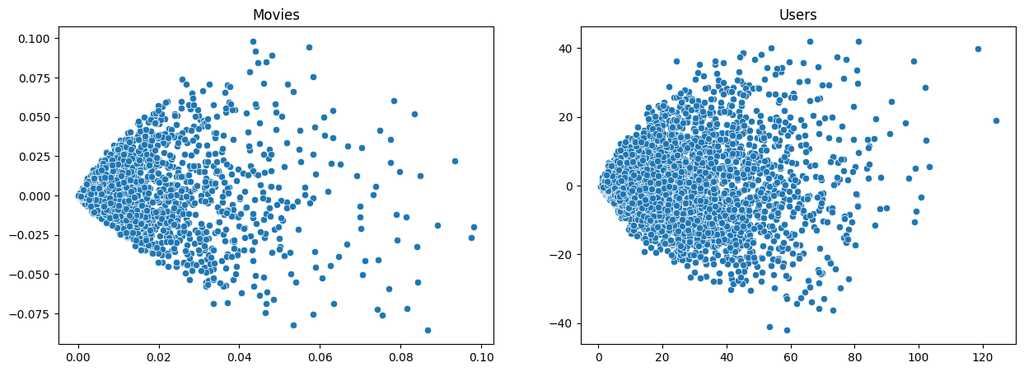

```python
##visualize TSVD components
svd1 = TruncatedSVD(n_components=2)
latent_matrix1 = svd1.fit_transform(csr_matrix(user_item_matrix))

fig, axes = plt.subplots(1, 2, figsize=(15, 5))

sns.scatterplot(x=svd1.components_.T[:, 0], y=svd1.components_.T[:, 1],  ax=axes[0], palette='viridis') #hue=labels,
axes[0].set_title('Movies')

sns.scatterplot(x=latent_matrix1[:, 0], y=latent_matrix1[:, 1],  ax=axes[1], palette='viridis') #hue=labels,
axes[1].set_title('Users')

plt.show()
```

```python
from sklearn.metrics.pairwise import cosine_similarity

user_pearson_matrix=(pd.DataFrame(latent_matrix.T,columns=user_item_matrix.index)).corr(method='pearson')
user_pearson_matrix=pd.DataFrame(user_pearson_matrix,index=user_item_matrix.index,columns=user_item_matrix.index)
item_pearson_matrix=(pd.DataFrame(svd.components_,columns=[item[1] for item in user_item_matrix.columns])).corr(method='pearson')
item_pearson_matrix=pd.DataFrame(item_pearson_matrix,index=[item[1] for item in user_item_matrix.columns],columns=[item[1] for item in user_item_matrix.columns])

user_cosinesim_matrix=cosine_similarity(pd.DataFrame(latent_matrix,index=user_item_matrix.index))
user_cosinesim_matrix=pd.DataFrame(user_cosinesim_matrix,index=user_item_matrix.index,columns=user_item_matrix.index)
item_cosinesim_matrix=cosine_similarity(pd.DataFrame(svd.components_.T,index=[item[1] for item in user_item_matrix.columns]))
item_cosinesim_matrix=pd.DataFrame(item_cosinesim_matrix,index=[item[1] for item in user_item_matrix.columns],columns=[item[1] for item in user_item_matrix.columns])
```

### Evaluating Overlap, K-precison and releventitems metrics from the matrices

```
===============================================
Demonstration from user-user method using pearson correlation

==============================
UserID:  3975

perc_overlap: 0.0
K_precision: 0.8571428571428571
relevant_items_matched: 0.10344827586206896
+--------------------------------------+-------------+-------------------------+
|          Recommended Movies          | User_Rating | Neighbors_mean_rating/V |
|                                      |             |          olume          |
+--------------------------------------+-------------+-------------------------+
|    raiders of the lost ark (1981)    |     4.0     |          4.8/5          |
+--------------------------------------+-------------+-------------------------+
|            aliens (1986)             |     nan     |          4.6/5          |
+--------------------------------------+-------------+-------------------------+
|      usual suspects, the (1995)      |     4.0     |          4.6/5          |
+--------------------------------------+-------------+-------------------------+
|           die hard (1988)            |     4.0     |          4.4/5          |
+--------------------------------------+-------------+-------------------------+
|  e.t. the extra-terrestrial (1982)   |     2.0     |          4.4/5          |
+--------------------------------------+-------------+-------------------------+
|      back to the future (1985)       |     nan     |          4.2/5          |
+--------------------------------------+-------------+-------------------------+
|         pulp fiction (1994)          |     4.0     |          4.2/5          |
+--------------------------------------+-------------+-------------------------+
|  terminator 2: judgment day (1991)   |     nan     |          4.2/5          |
+--------------------------------------+-------------+-------------------------+
| indiana jones and the last crusade ( |     4.0     |          4.2/5          |
|                1989)                 |             |                         |
+--------------------------------------+-------------+-------------------------+
|        godfather, the (1972)         |     5.0     |          4.2/5          |
+--------------------------------------+-------------+-------------------------+
avg % overlap: 0.2596253810575002
avg K-Precision: 0.8425254257332072
avg relevant items matched: 0.12210775920303703
```

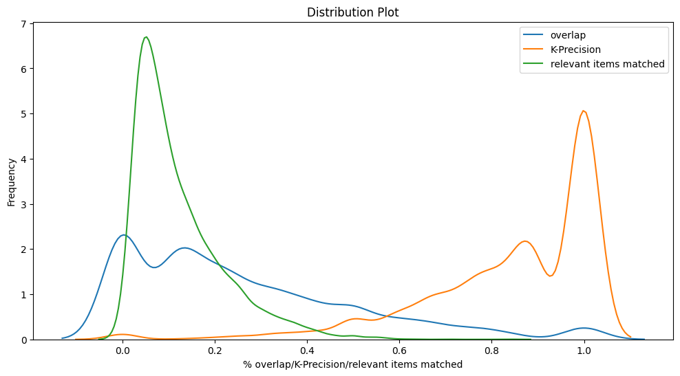

```
===============================================
Demonstration from user-user method using cosine similarity

==============================
UserID:  5228

perc_overlap: 0.8333333333333334
K_precision: 1.0
relevant_items_matched: 0.3157894736842105
+----------------------------------+-------------+-----------------------------+
|        Recommended Movies        | User_Rating | Neighbors_mean_rating/Volum |
|                                  |             |              e              |
+----------------------------------+-------------+-----------------------------+
|      american beauty (1999)      |     5.0     |            5.0/5            |
+----------------------------------+-------------+-----------------------------+
| shawshank redemption, the (1994) |     nan     |            5.0/5            |
+----------------------------------+-------------+-----------------------------+
|        goodfellas (1990)         |     nan     |            4.4/5            |
+----------------------------------+-------------+-----------------------------+
|    saving private ryan (1998)    |     5.0     |            5.0/4            |
+----------------------------------+-------------+-----------------------------+
|     sixth sense, the (1999)      |     4.0     |            4.5/4            |
+----------------------------------+-------------+-----------------------------+
|       pulp fiction (1994)        |     5.0     |            4.5/4            |
+----------------------------------+-------------+-----------------------------+
|   being john malkovich (1999)    |     5.0     |           4.25/4            |
+----------------------------------+-------------+-----------------------------+
|      green mile, the (1999)      |     4.0     |            4.0/4            |
+----------------------------------+-------------+-----------------------------+
|     l.a. confidential (1997)     |     nan     |           3.75/4            |
+----------------------------------+-------------+-----------------------------+
| silence of the lambs, the (1991) |     nan     |           4.67/3            |
+----------------------------------+-------------+-----------------------------+
avg % overlap: 0.2603263954588458
avg K-Precision: 0.8452737044044991
avg relevant items matched: 0.1225771075634473
```

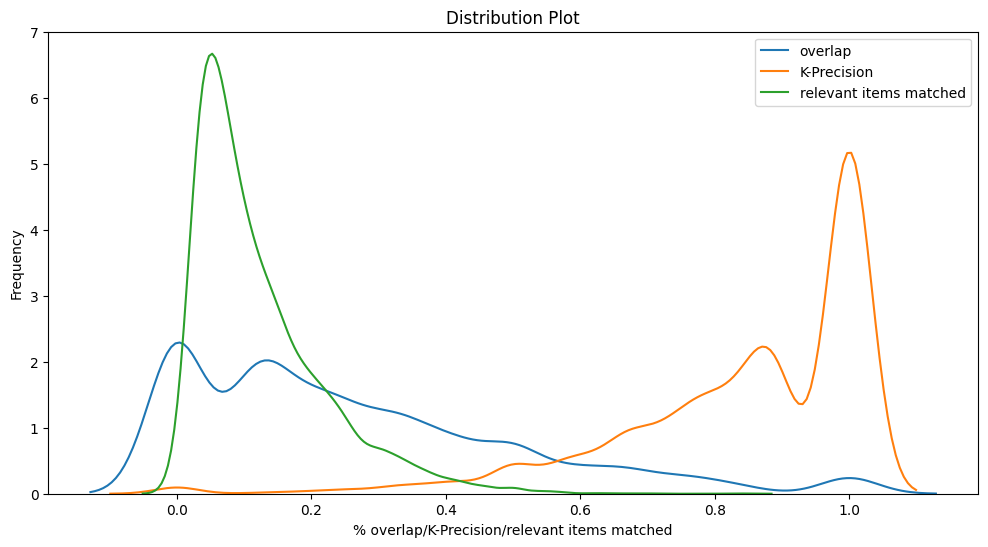

```
===============================================
Demonstration from item-item method using cosine similarity

==============================
UserID:  1967

perc_overlap: 0.3333333333333333
K_precision: 1.0
relevant_items_matched: 0.2
+-------------------+------------+--------+-------+----------------+-----------+
| Recommended_Movie | Avg_Rating | Volume | user_ |  user_movies   | num_time_ |
|                   |            |        | ratin |                | recommend |
|                   |            |        |   g   |                |    ed     |
+-------------------+------------+--------+-------+----------------+-----------+
| american beauty ( |   4.317    | 3428.0 |  4.0  | ['being john m |     1     |
|       1999)       |            |        |       | alkovich (1999 |           |
|                   |            |        |       |      )']       |           |
+-------------------+------------+--------+-------+----------------+-----------+
| saving private ry |   4.337    | 2653.0 |  0.0  | ['american bea |     1     |
|     an (1998)     |            |        |       |  uty (1999)']  |           |
+-------------------+------------+--------+-------+----------------+-----------+
|   fargo (1996)    |   4.255    | 2513.0 |  0.0  | ['american bea |     1     |
|                   |            |        |       |  uty (1999)']  |           |
+-------------------+------------+--------+-------+----------------+-----------+
| pulp fiction (199 |   4.278    | 2171.0 |  0.0  | ['american bea |     1     |
|        4)         |            |        |       |  uty (1999)']  |           |
+-------------------+------------+--------+-------+----------------+-----------+
| shakespeare in lo |   4.127    | 2369.0 |  4.0  | ['being john m |     1     |
|     ve (1998)     |            |        |       | alkovich (1999 |           |
|                   |            |        |       |      )']       |           |
+-------------------+------------+--------+-------+----------------+-----------+
| being john malkov |   4.125    | 2241.0 |  4.0  | ['american bea |     1     |
|    ich (1999)     |            |        |       |  uty (1999)']  |           |
+-------------------+------------+--------+-------+----------------+-----------+
| fight club (1999) |   4.077    | 1451.0 |  0.0  | ['being john m |     1     |
|                   |            |        |       | alkovich (1999 |           |
|                   |            |        |       |      )']       |           |
+-------------------+------------+--------+-------+----------------+-----------+
|  election (1999)  |    3.93    | 1522.0 |  0.0  | ['being john m |     1     |
|                   |            |        |       | alkovich (1999 |           |
```

[output cut: 51 more lines]

```
|    (1974)    |            |        |      |                         |        |
+--------------+------------+--------+------+-------------------------+--------+
| monty python |   4.335    | 1599.0 | 0.0  | ['life is beautiful (la |   1    |
|  and the hol |            |        |      |  vita è bella) (1997)'] |        |
| y grail (197 |            |        |      |                         |        |
|      4)      |            |        |      |                         |        |
+--------------+------------+--------+------+-------------------------+--------+
| indiana jone |   4.133    | 1628.0 | 0.0  | ['princess bride, the ( |   1    |
| s and the la |            |        |      |         1987)']         |        |
| st crusade ( |            |        |      |                         |        |
|    1989)     |            |        |      |                         |        |
+--------------+------------+--------+------+-------------------------+--------+
| amadeus (198 |   4.252    | 1382.0 | 4.0  | ['one flew over the cuc |   1    |
|      4)      |            |        |      |   koos nest (1975)']    |        |
+--------------+------------+--------+------+-------------------------+--------+
```

```
(-1, -1, -1)
```

```python
n_users=5
smooth_parameter=0.5
n_items=10

def agg_movies(x):
    movies=x[x>0].sort_values(ascending=False).droplevel(0).reset_index()
    movies.columns=['Title','rating']
    return movies



def check_random_user_recommendations(user_matrix,user_item_matrix,users=[],get_avg_metrics=False):
    if len(users)==0:
        users=np.random.choice(list(user_item_matrix.index.values),3)

    if get_avg_metrics:
        users=list(user_item_matrix.index.values)

    overlap=[]
    kprec=[]
    relevitems=[]

    for user in users:

        #picking n_users similar users
        similar_users=user_matrix[user].sort_values(ascending=False).iloc[1:n_users+1].index
        movies=user_item_matrix.loc[similar_users].apply(lambda x:agg_movies(x),axis=1)
        movies=pd.DataFrame(np.concatenate(movies.values),columns=['Title','rating'])
        movies=movies.groupby(['Title']).agg(rating=('rating','mean'),volume=('rating','count')).reset_index()

        popular_indexes=(((movies['rating']-movies['rating'].mean())/movies['rating'].std())*smooth_parameter+\
        ((movies['volume']-movies['volume'].mean())/movies['volume'].std())*(1-alpha)).sort_values(ascending=False)[:n_items].index

        movies=movies.loc[popular_indexes].reset_index(drop=True)

        movies_from_user=user_item_matrix.loc[user]
        movies_from_user=movies_from_user[movies_from_user>0].droplevel(0).sort_values(ascending=False)

        movies['user_rating']=np.nan
        for idx,row in movies.iterrows():
            try:
                movies.loc[idx,'user_rating']=movies_from_user[row.Title]
            except:
                pass


        movies_from_user=list(movies_from_user.index[:n_items])
        valid_recs=(~(movies.user_rating.isna())).sum()
        overlaps=len(set(movies.loc[(~(movies.user_rating.isna())),'Title'].values).intersection(movies_from_user))

        K_prec_user_mat=user_item_matrix.loc[user]
        K_prec_user_mat=K_prec_user_mat[K_prec_user_mat>=4].droplevel(0).sort_values(ascending=False).index
        K_precision=len(set(movies.loc[(~(movies.user_rating.isna())),'Title'].values).intersection(K_prec_user_mat))
        if valid_recs==0:
            avg_perc_overlap=0
            avg_k_precision=0
        else:
            avg_perc_overlap=overlaps/valid_recs
            avg_k_precision=K_precision/valid_recs

        if len(K_prec_user_mat)==0:
            avg_relevant_items_matched=0
        else:
            avg_relevant_items_matched=K_precision/len(K_prec_user_mat)

        overlap.append(avg_perc_overlap)
        kprec.append(avg_k_precision)
        relevitems.append(avg_relevant_items_matched)
        if not get_avg_metrics:
            print('==============================\nUserID: ',user)
            print('\nperc_overlap: {}\nK_precision: {}\nrelevant_items_matched: {}'.format(avg_perc_overlap,avg_k_precision,avg_relevant_items_matched))

            movies['Neighbors_mean_rating/Volume']=movies.rating.astype(float).round(2).astype(str)+'/'+movies.volume.round(0).astype(str)
            movies.drop(['rating','volume'],axis=1,inplace=True)
            movies.columns=['Recommended Movies','User_Rating','Neighbors_mean_rating/Volume']
            table = BeautifulTable()
            for ind,row in movies.iterrows():
                table.rows.append(row)
            table.columns.header = movies.columns
            print(table)
            return -1,-1,-1
    return overlap,kprec,relevitems


def check_random_item_recommendation(item_matrix,user_item_matrix,users=[],get_avg_metrics=False):
    item_user_matrix=user_item_matrix.T.droplevel(0)
    if len(users)==0:
        users=np.random.choice(list(user_item_matrix.index.values),3)

    if get_avg_metrics:
        users=list(user_item_matrix.index.values)

    overlap=[]
    kprec=[]
    relevitems=[]

    for user in users:
        user_items = user_item_matrix.loc[user]
        user_items = user_items[user_items >=4].droplevel(0).sort_values(ascending=False).iloc[1:n_items+1] ##recommendations based on liked movies

        recommended_items =pd.DataFrame()

        for item in user_items.index:
            # similar items
            similar_items = item_matrix[item].sort_values(ascending=False).iloc[1:n_items+1]
            similar_items=item_user_matrix.loc[similar_items.index].\
            apply(lambda x:pd.Series([x[x>0].mean(),x[x>0].count()]),axis=1).reset_index()

            similar_items.columns=['Recommended_Movie','Avg_Rating','Volume']
            similar_items['user_rating']=np.nan
            similar_items['user_movie']=item
            for idx,row in similar_items.iterrows():
                try:
                    similar_items.loc[idx,'user_rating']=item_user_matrix.loc[row.Recommended_Movie,user]
                except:
                    pass

            recommended_items=pd.concat([recommended_items,similar_items],axis=0,ignore_index=True)


        #print(recommended_items.shape)
        try:
            r1=recommended_items.groupby(['Recommended_Movie','Avg_Rating','Volume','user_rating']).apply(lambda x:list(x.user_movie.values)).reset_index()
            r2=recommended_items.groupby(['Recommended_Movie','Avg_Rating','Volume','user_rating']).user_movie.count().reset_index()
            r1.columns=['Recommended_Movie','Avg_Rating','Volume','user_rating','user_movies']
            r2.columns=['Recommended_Movie','Avg_Rating','Volume','user_rating','num_time_recommended']
            r1=r1.merge(r2,how='left',on=['Recommended_Movie','Avg_Rating','Volume','user_rating'])

            popular_indexes=(((r1['Avg_Rating']-r1['Avg_Rating'].mean())/r1['Avg_Rating'].std())*smooth_parameter+\
            ((r1['Volume']-r1['Volume'].mean())/r1['Volume'].std())*(1-alpha)).sort_values(ascending=False)[:n_items].index

            r1=r1.loc[popular_indexes].reset_index(drop=True)

            movies_from_user=user_item_matrix.loc[user]
            movies_from_user=movies_from_user[movies_from_user>0].droplevel(0).sort_values(ascending=False)
            movies_from_user=list(movies_from_user.index[:n_items])

            valid_recs=(~(r1.user_rating==0)).sum()
            overlaps=len(set(r1.loc[(~(r1.user_rating==0)),'Recommended_Movie'].values).intersection(movies_from_user))

            K_prec_user_mat=user_item_matrix.loc[user]
            K_prec_user_mat=K_prec_user_mat[K_prec_user_mat>=4].droplevel(0).sort_values(ascending=False).index
            K_precision=len(set(r1.loc[(~(r1.user_rating==0)),'Recommended_Movie'].values).intersection(K_prec_user_mat))
            if valid_recs==0:
                avg_perc_overlap=0
                avg_k_precision=0
            else:
                avg_perc_overlap=overlaps/valid_recs
                avg_k_precision=K_precision/valid_recs

            if len(K_prec_user_mat)==0:
                avg_relevant_items_matched=0
            else:
                avg_relevant_items_matched=K_precision/len(K_prec_user_mat)

            overlap.append(avg_perc_overlap)
            kprec.append(avg_k_precision)
            relevitems.append(avg_relevant_items_matched)
        except:
            overlap.append(0)
            kprec.append(0)
            relevitems.append(0)
        if not get_avg_metrics:
            print('==============================\nUserID: ',user)
            print('\nperc_overlap: {}\nK_precision: {}\nrelevant_items_matched: {}'.format(avg_perc_overlap
                                                                                           ,avg_k_precision
                                                                                          ,avg_relevant_items_matched))

            table = BeautifulTable()
            for ind,row in r1.iterrows():
                table.rows.append(row)
            table.columns.header = r1.columns
            print(table)
            return -1,-1,-1
    return overlap,kprec,relevitems

def plott(overlap,kprec,relevitems):
    plt.figure(figsize=(12, 6))

    print('avg % overlap:',np.mean(np.array(overlap)))
    print('avg K-Precision:',np.mean(np.array(kprec)))
    print('avg relevant items matched:',np.mean(np.array(relevitems)))
    sns.kdeplot(np.array(overlap), label='{}'.format('overlap'), palette='viridis')
    sns.kdeplot(np.array(kprec), label='{}'.format('K-Precision'), palette='viridis')
    sns.kdeplot(np.array(relevitems), label='{}'.format('relevant items matched'), palette='viridis')

    plt.title('Distribution Plot')
    plt.xlabel('% overlap/K-Precision/relevant items matched')
    plt.ylabel('Frequency')
    plt.legend()
    plt.show()


print('===============================================\nDemonstration from user-user method using pearson correlation\n')
check_random_user_recommendations(user_pearson_matrix,user_item_matrix,[])
overlap,kprec,relevitems=check_random_user_recommendations(user_pearson_matrix,user_item_matrix,[],True)
plott(overlap,kprec,relevitems)

print('===============================================\nDemonstration from user-user method using cosine similarity\n')
check_random_user_recommendations(user_cosinesim_matrix,user_item_matrix,[])
overlap,kprec,relevitems=check_random_user_recommendations(user_cosinesim_matrix,user_item_matrix,[],True)
plott(overlap,kprec,relevitems)

print('===============================================\nDemonstration from item-item method using cosine similarity\n')
check_random_item_recommendation(item_cosinesim_matrix,user_item_matrix,[])
#overlap,kprec,relevitems=check_random_item_recommendation(item_cosinesim_matrix.iloc[:30,:30],user_item_matrix,[],True)
#plott(overlap,kprec,relevitems)


print('===============================================\nDemonstration from item-item method using pearson correlation\n')
check_random_item_recommendation(item_pearson_matrix,user_item_matrix,users=[])
#overlap,kprec,relevitems=check_random_item_recommendation(item_pearson_matrix.iloc[:30,:30],user_item_matrix,[],True)
#plott(overlap,kprec,relevitems)
```

### Building a Recommender System based Pearson Correlation. (based on steps from optional section)

```python
for user in ratings_data.UserID.unique()[:3]:
    movies=ratings_data.loc[ratings_data.UserID==user].Title.unique()
    top10_movies=ratings_data.loc[ratings_data.UserID==user].sort_values('Rating',ascending=False).Title.values[:10]
    df=pd.DataFrame()
    for movie in movies:
        sim_u=ratings_data.loc[(ratings_data.UserID!=user)&(ratings_data.Title==movie),'UserID'].to_frame()
        sim_u['Title']=movie
        sim_u.drop_duplicates(keep='first',inplace=True)
        df=pd.concat([df,sim_u],axis=0,ignore_index=True)

    df=df.groupby(['UserID']).Title.count().sort_values(ascending=False)[:100]
    similarity_scores=user_pearson_matrix.loc[df.index,user].sort_values(ascending=False)[:10].reset_index()
    similarity_scores.columns=['UserID','cor_r']
    weights_df=pd.DataFrame()
    for idx,row in similarity_scores.iterrows():
        weights=ratings_data.loc[ratings_data.UserID==row.UserID,['UserID','Title','Rating']].copy()
        weights.loc[:,'Rating']=weights.Rating*row.cor_r
        weights['cor_r']=row.cor_r
        weights_df=pd.concat([weights_df,weights],axis=0,ignore_index=True)

    weights_df=weights_df.groupby(['Title']).agg(Rating=('Rating','sum'),cor_r=('cor_r','sum'))
    weights_df.loc[:,'Rating']=weights_df['Rating']/weights_df['cor_r']
    Recommended_movies=weights_df.sort_values('Rating',ascending=False).iloc[:10].index

    print('========================================\nUserID: ',user)
    print('\nTop rated movies watched by user: ',list(top10_movies))
    print('\nTop Recommendations: ',list(Recommended_movies))
```

```
========================================
UserID:  1

Top rated movies watched by user:  ['one flew over the cuckoos nest (1975)', 'dumbo (1941)', 'toy story (1995)', 'awakenings (1990)', 'rain man (1988)', 'schindlers list (1993)', 'cinderella (1950)', 'sound of music, the (1965)', 'pocahontas (1995)', 'mary poppins (1964)']

Top Recommendations:  ['manchurian candidate, the (1962)', 'they shoot horses, dont they? (1969)', 'ice storm, the (1997)', 'it happened one night (1934)', 'whos afraid of virginia woolf? (1966)', 'lady vanishes, the (1938)', 'shallow grave (1994)', 'creature comforts (1990)', 'bad seed, the (1956)'…
========================================
UserID:  2

Top rated movies watched by user:  ['shine (1996)', 'simon birch (1998)', 'green mile, the (1999)', 'gandhi (1982)', 'braveheart (1995)', 'close encounters of the third kind (1977)', 'on the waterfront (1954)', 'amadeus (1984)', 'remains of the day, the (1993)', 'jurassic park (1993)']

Top Recommendations:  ['music of the heart (1999)', 'splendor in the grass (1961)', 'godzilla (gojira) (1954)', 'rope (1948)', 'soylent green (1973)', 'mystery, alaska (1999)', 'ballad of narayama, the (narayama bushiko) (1982)', 'ipcress file, the (1965)', 'burnt by the sun (utomlyonnye solntsem) (…
========================================
UserID:  3

Top rated movies watched by user:  ['butch cassidy and the sundance kid (1969)', 'edge, the (1997)', 'bugs life, a (1998)', 'princess bride, the (1987)', 'raiders of the lost ark (1981)', 'star wars: episode iv - a new hope (1977)', 'young guns (1988)', 'blade (1998)', 'caddyshack (1980)', 'stand by…

Top Recommendations:  ['mumford (1999)', 'still crazy (1998)', 'tora! tora! tora! (1970)', 'blood in, blood out (a.k.a. bound by honor) (1993)', 'adventures of robin hood, the (1938)', 'blast from the past (1999)', 'wild bunch, the (1969)', 'stalag 17 (1953)', 'black sheep (1996)', 'ghost in the she…
```

**Modelling**

```python
def train_test(dd,x_cols,y_col,stratify_col=None):
    d=dd.copy()
    d=d.sample(frac=1,random_state=0).reset_index(drop=True)
    xtrain,xtest,ytrain,ytest=train_test_split(d.loc[:,x_cols]
                                               ,d.loc[:,y_col]
                                               ,test_size=0.1  #10% test_size
                                               ,random_state=0,stratify=stratify_col)
    return xtrain,xtest,ytrain,ytest


##Standardize

def filter_numeric(data,coll):
    enum_coll=list(enumerate(coll))
    cols=data.select_dtypes(include=['number']).columns
    cc=[]
    for col in cols:
        if (data[col].nunique()>2) or\
        ((sorted(list(data[col].unique()))!=[0,1]) and\
        (sorted(list(data[col].unique()))!=[0]) and\
        (sorted(list(data[col].unique()))!=[1])):
            cc.append(col)

    cols=cc
    numeric_cols=list(set(cols).intersection(set(coll)))
    li=[sett[1] for sett in enum_coll if sett[1] in numeric_cols]
    return li

def standardize_data(d,cols,strategy='standard'):
    if strategy=='standard':
        scalar=StandardScaler()
    else:
        scalar=MinMaxScaler()
    data=d.copy()
    cols=filter_numeric(data,cols)
    data.loc[:,cols]=pd.DataFrame(scalar.fit_transform(data[cols]),columns=cols,index=data.index)

    return data,scalar,cols

def transform_standardize_data(d,cols,scalar):
    data=d.copy()
    data.loc[:,cols]=pd.DataFrame(scalar.transform(data[cols]),columns=cols,index=data.index)
    return data

def revtransform_standardize_data(d,cols,scalar):
    data=d.copy()
    data.loc[:,cols]=pd.DataFrame(scalar.inverse_transform(data[cols]),columns=cols,index=data.index)
    return data

## One hot encoding
def dummy_str_col(d,cols):
    data=d.copy()
    drop_str_cols=[]
    str_cols=cols
    for str_col in str_cols:
        str_data=pd.get_dummies(data.loc[:,str_col]).astype(int)
        str_data.columns=[str_col+'_'+str(col) for col in str_data.columns]
        drop_str_cols.append(str_data.columns[-1])
        str_data.drop(str_data.columns[-1],axis=1,inplace=True)

        data.drop(str_col,axis=1,inplace=True)
        data=pd.concat([data,str_data],axis=1)
    return data,drop_str_cols

def test_str_col(d,cols,drop_str_cols):
    data=d.copy()
    str_cols=cols
    for str_col in str_cols:
        str_data=pd.get_dummies(data.loc[:,str_col]).astype(int)
        str_data.columns=[str_col+'_'+str(col) for col in str_data.columns]
        data.drop(str_col,axis=1,inplace=True)
        data=pd.concat([data,str_data],axis=1)

    for drop_col in drop_str_cols:
        data.drop(drop_col,axis=1,inplace=True)

    return data
```

```python
cleaned_df1=ratings_data.copy()
cleaned_df1.drop(['MovieID','Occupation','Timestamp','Genres'],axis=1,inplace=True)

user_cols=['UserID','Gender', 'Age']
user_factors=cleaned_df1[user_cols].copy().drop_duplicates(keep='first').set_index('UserID')
user_factors,drop_str_cols=dummy_str_col(user_factors,user_factors.columns)

movie_cols=['Title', 'Action', 'Adventure', 'Animation', 'Children', 'Comedy', 'Crime',
       'Documentary', 'Drama', 'Fantasy', 'Film_Noir', 'Horror', 'Musical',
       'Mystery', 'Romance', 'Sci_Fi', 'Thriller', 'War', 'Western','release_date']

movie_factors=cleaned_df1[movie_cols].copy().drop_duplicates(keep='first').set_index('Title')
movie_factors,drop_str_cols=dummy_str_col(movie_factors,['release_date'])

stratify_col=ratings_data.Rating.astype(str)
for cat in categorical_vars:
    if cat in('Gender','Age','Occupation','rated_year','rated_weeknum','release_date'
             ,'Comedy','Drama','Action','Thriller'):   ##most volume from comedy and drama
        continue
    stratify_col=stratify_col+ratings_data[cat].astype(str)

xtrain,xtest,ytrain,ytest=train_test(cleaned_df1,[col for col in cleaned_df1 if col!='Rating'],'Rating',stratify_col)

xtrain.reset_index(drop=True,inplace=True)
xtest.reset_index(drop=True,inplace=True)
ytrain.reset_index(drop=True,inplace=True)
ytest.reset_index(drop=True,inplace=True)

train_df=pd.concat([xtrain,ytrain],axis=1)
test_df=pd.concat([xtest,ytest],axis=1)

train_matrix = train_df.groupby(['UserID','Title']).Rating.mean().fillna(0).reset_index()
rating_year_matrix = cleaned_df1.groupby(['UserID','Title']).rated_year.mean().unstack().fillna(0)

user_factors=user_factors.merge(rating_year_matrix,how='left',left_index=True,right_index=True)

test_matrix = test_df.groupby(['UserID','Title']).Rating.mean().fillna(0).reset_index()

train_matrix.rename({'UserID':'UserId','Title':'ItemId'},axis=1,inplace=True)
test_matrix.rename({'UserID':'UserId','Title':'ItemId'},axis=1,inplace=True)
user_factors.index.name='UserId'
movie_factors.index.name='ItemId'

user_factors.reset_index(inplace=True)
movie_factors.reset_index(inplace=True)
```

### Using CMFREC Matrix Factorization with user and movie context

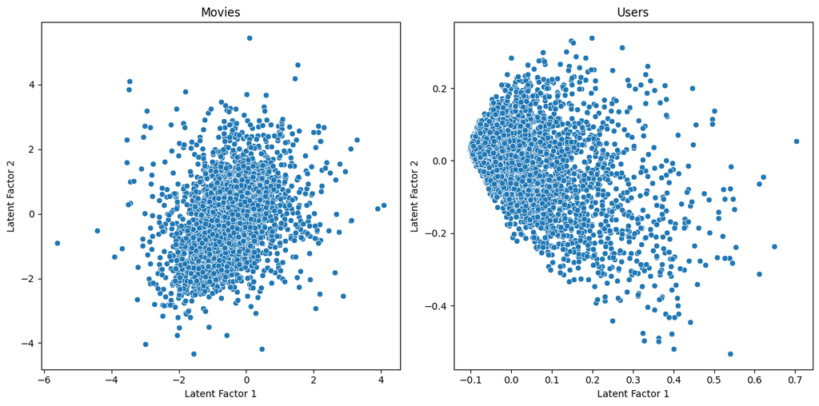

```python
from cmfrec import CMF

model = CMF(
    k=2,
    method="als", niter=50, lambda_=0.1,
    user_bias=True,  # Include user biases
    item_bias=True,  # Include item biases
    verbose=False
)

model1 = CMF(
    k=4,
    method="als", niter=50, lambda_=0.1,
    user_bias=True,  # Include user biases
    item_bias=True,  # Include item biases
    verbose=False
)

model.fit(train_matrix, U=user_factors, I=movie_factors)
model1.fit(train_matrix, U=user_factors, I=movie_factors)

user_factorss = model.A_
item_factorss = model.B_

fig, axes = plt.subplots(1, 2, figsize=(12, 6))

# Movies (Items)
sns.scatterplot(x=item_factorss[:, 0], y=item_factorss[:, 1], ax=axes[0], palette='viridis')
axes[0].set_title('Movies')
axes[0].set_xlabel('Latent Factor 1')
axes[0].set_ylabel('Latent Factor 2')

# Users
sns.scatterplot(x=user_factorss[:, 0], y=user_factorss[:, 1], ax=axes[1], palette='viridis')
axes[1].set_title('Users')
axes[1].set_xlabel('Latent Factor 1')
axes[1].set_ylabel('Latent Factor 2')

plt.tight_layout()
plt.show()
```

```python
## visuals are too localized at d=2
```

```python
def evaluate_model(data_df, model):


    predicted_rating = model.predict(user=data_df.UserID.values, item=data_df.Title.values)
    true_rating=data_df.Rating.values
    predictions = list(zip(true_rating,predicted_rating))
    #print(predictions)

    # predictions to a DataFrame
    predictions_df = pd.DataFrame(predictions, columns=['true_rating', 'predicted_rating'])

    # evaluation metrics
    mape = np.mean(np.abs((predictions_df['true_rating'] - predictions_df['predicted_rating']) / predictions_df['true_rating'])) * 100
    rmse = np.sqrt(np.mean((predictions_df['true_rating'] - predictions_df['predicted_rating']) ** 2))
    mse = np.mean((predictions_df['true_rating'] - predictions_df['predicted_rating']) ** 2)

    return mape, rmse, mse

train_mape, train_rmse, train_mse = evaluate_model(train_df, model1)
print(f"Training Set - MAPE: {train_mape:.2f}%, RMSE: {train_rmse:.4f}, MSE: {train_mse:.4f}")

# Evaluate on test set
test_mape, test_rmse, test_mse = evaluate_model(test_df, model1)
print(f"Test Set - MAPE: {test_mape:.2f}%, RMSE: {test_rmse:.4f}, MSE: {test_mse:.4f}")
```

```
Training Set - MAPE: 26.95%, RMSE: 0.8806, MSE: 0.7754
Test Set - MAPE: 27.71%, RMSE: 0.9037, MSE: 0.8166
```

```
avg % overlap: 0.030709850646081557
avg K-Precision: 0.030793757341835877
avg relevant items matched: 0.0027858781833955126
```

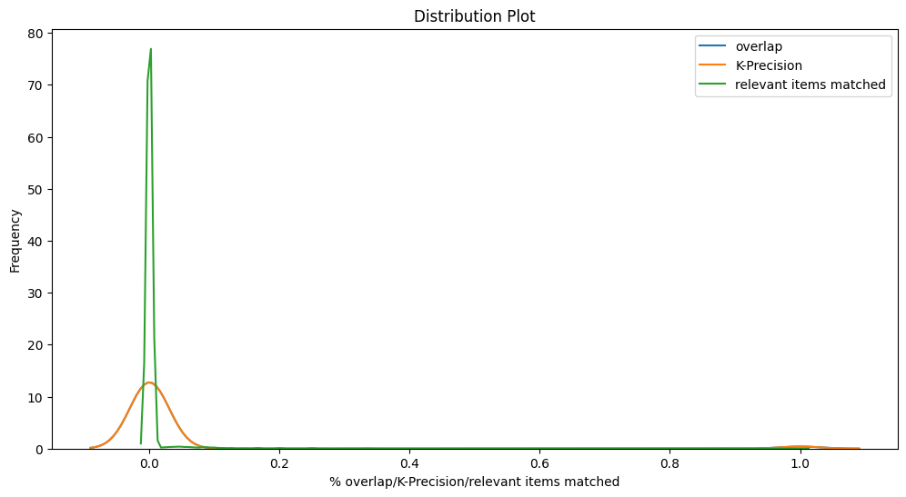

```python
overlap= []
kprecc=[]
ritemss=[]

n = 20
for user in test_df.UserID.unique():
    top_items = model1.topN(user=user, n=n)
    user_movies = test_df.loc[(test_df.UserID==user)].Title
    valid_rec = set(top_items).intersection(set(user_movies))
    relevant_items = test_df.loc[(test_df.UserID==user) & (test_df.Rating>=4)].Title

    ov = len(set(test_df.loc[(test_df.UserID==user)].sort_values(by='Rating', ascending=False).head(n).Title).intersection(set(valid_rec)))
    try:
        kprec = len(set(top_items).intersection(set(relevant_items))) / len(valid_rec)
    except:
        kprec = 0

    try:
        ritems = len(set(top_items).intersection(set(relevant_items))) / len(set(relevant_items))
    except:
        ritems = 0
    try:
      overlap.append(ov/len(valid_rec))
    except:
      overlap.append(0)
    kprecc.append(kprec)
    ritemss.append(ritems)


plott(overlap,kprecc,ritemss)
```

### Questionnaire:

**1. Users of which age group have watched and rated the most number of movies?**  
The most active age group in rating movies is 25-34 years old, representing 39% of the dataset. This demographic likely includes working professionals, students, and media critics.

**2. Users belonging to which profession have watched and rated the most movies?**  
College/graduate students and individuals in the "Other" occupation category each contribute 13% of the ratings. Executive/managerial roles account for 10.5%.

**3. Most of the users in our dataset who’ve rated the movies are Male. (T/F)**  
The dataset shows a significant gender imbalance, with 75% of the ratings provided by male users.

**4. Most of the movies present in our dataset were released in which decade?**  
A majority of the movies in the dataset were released in the 1990s, comprising 53% of the dataset.

```python
ratings_data.release_date.astype(str).str[-2].value_counts(normalize=True)[:3]
```

| release_date | proportion |
| --- | --- |
| 9 | 0.532732 |
| 8 | 0.224009 |
| 7 | 0.082535 |

**dtype:** float64

**5. The movie with maximum no. of ratings is ___.**  
"American Beauty" has the highest number of ratings in the dataset.

```python
ratings_data.Title.value_counts(normalize=True)[:5]
```

| Title | proportion |
| --- | --- |
| american beauty (1999) | 0.003427 |
| star wars: episode iv - a new hope (1977) | 0.002990 |
| star wars: episode v - the empire strikes back (1980) | 0.002989 |
| star wars: episode vi - return of the jedi (1983) | 0.002882 |
| jurassic park (1993) | 0.002671 |

**dtype:** float64

```python
item_cosinesim_matrix['liar liar (1997)'].sort_values(ascending=False)[1:4].index
```

```
Index(['ace ventura: pet detective (1994)', 'dumb & dumber (1994)',
       'cool runnings (1993)'],
      dtype='object')
```

**7. On the basis of approach, Collaborative Filtering methods can be classified into item-based and user-based.**  
**8. Pearson Correlation ranges between -1 to 1 whereas, Cosine Similarity belongs to the interval between -1 to 1.**  
**9. Mention the RMSE and MAPE that you got while evaluating the Matrix Factorization model.**  
MAPE: 27.71%, RMSE: 0.9037

```python
K = 2
dd=np.array([[1,0],[3,7]])

P = np.random.normal(size=(dd.shape[0], K))
Q = np.random.normal(size=(dd.shape[1], K))

def matrix_factorization(R, P, Q, K, steps=10000, alpha=0.0002, beta=0.02):
    Q = Q.T
    for step in range(steps):
        for i in range(len(R)):
            for j in range(len(R[i])):
#                 if R[i][j] == 0:
#                     continue
                eij = R[i][j] - np.dot(P[i,:],Q[:,j])
                for k in range(K):
                    x = P[i][k]
                    P[i][k] += alpha * (2 * eij * Q[k][j]) # - beta * P[i][k]) -- regularization parameter
                    Q[k][j] += alpha * (2 * eij * x) # - beta * Q[k][j])
    return P, Q.T


P_, Q_ =  matrix_factorization(dd.copy(), P.copy(), Q.copy(), K)

P_.round(2)
```

```
array([[-0.59, -0.18],
       [-1.15,  2.44]])
```

**Observations**  
1. There is a noticeable class imbalance in the ratings, with the majority being 3, 4, or 5-star ratings, which account for 82% of the dataset.  
2. Comedy is the most rated genre, followed closely by Drama. Notably, people under 35 tend to rate comedy movies more frequently.  
3. There is a significant correlation between users' age and their occupations.  
4. A large proportion of movies are rated during week 47 (the last week of November - 17%) and week 31 (the last week of July or the first week of August - 8%), likely due to seasonal factors such as holidays and summer breaks.  
5. Ratings for genres such as Documentary, Animation, Children, Sci-Fi, and Horror have declined from 2000 to 2003. In contrast, Crime, Film Noir, Musical, Romance, and War genres have seen an increase in ratings during this period.  
6. There is a strong correlation between Animation and Children’s movies, as well as between Action, Adventure, and Sci-Fi genres.  
**Recommendations**  
1. Marketing strategies could be tailored towards the 25-34 age group, particularly focusing on genres like Comedy and Drama, which are popular within this demographic.  
2. Leveraging the seasonal spikes in ratings during specific weeks of the year (e.g., week 47 and week 31) could be beneficial for targeted promotions or new releases.  
3. Given the trends over time, content providers might focus on creating or acquiring more content in genres that are gaining popularity, such as Crime and Romance, while also revitalizing genres like Animation and Sci-Fi with fresh content.

### Supervised Modelling - Using XGBoost

```python
cleaned_df=ratings_data.copy()

cleaned_df.drop(['UserID','MovieID','Timestamp','Title','Genres','release_date'],axis=1,inplace=True)
one_hot_cols=['rated_year','rated_weeknum','Gender','Age']
cleaned_df.drop('Occupation',axis=1,inplace=True)
cleaned_df,drop_str_cols=dummy_str_col(cleaned_df,one_hot_cols)

stratify_col=ratings_data.Rating.astype(str)
for cat in categorical_vars:
    if cat in('Gender','Age','Occupation','rated_year','rated_weeknum','release_date'
             ,'Comedy','Drama','Action','Thriller'):   ##most volume from comedy and drama
        continue
    stratify_col=stratify_col+ratings_data[cat].astype(str)

xtrain,xtest,ytrain,ytest=train_test(cleaned_df,[col for col in cleaned_df if col!='Rating'],'Rating',stratify_col)

xtrain.reset_index(drop=True,inplace=True)
xtest.reset_index(drop=True,inplace=True)
ytrain.reset_index(drop=True,inplace=True)
ytest.reset_index(drop=True,inplace=True)
```

```python
xtrain_std,scalar,numeric_cols=standardize_data(xtrain,xtrain.columns)
xtest_std=transform_standardize_data(xtest,numeric_cols,scalar)
```

```python
def itertool_comb(params,estimator_pkl,key_to_ignore=['regressor','classifier']):
    param_list=[]
    for param in params:
        estimator=[value[0] for key,value in param.items() if key in key_to_ignore]
        keys=[key.split('__')[1] for key,value in param.items() if key not in key_to_ignore]
        values=[value for key,value in param.items() if key not in key_to_ignore]
        values=list(product(*values))
        iter_list=[]
        for i in range(len(values)):
            iter_dict=dict()
            for j in range(len(values[i])):
                iter_dict[keys[j]]=values[i][j]
            iter_list.append([estimator[0],iter_dict])
        for l in iter_list:
            param_list.append(l)

    par_dict={
        'param_grid':param_list,
        'checkpoint_index':0,  ##from param_list
        'best_param_index':None,
        'best_estimator':None,

        'best_val_mse': float('inf'),
        'best_val_mape': float('inf'),
        'best_val_rmse': float('inf'),

        'scaler':None
    }

    pickle.dump(par_dict,open(estimator_pkl,'wb'))


def accuracy_checks(y_test, y_pred):
    mse = mean_squared_error(y_test, y_pred)
    rmse = np.sqrt(mse)
    mape = mean_absolute_percentage_error(y_test, y_pred)

    print(f'MSE: {mse}\nRMSE: {rmse}\nMAPE: {mape}')
    return mse, rmse, mape

def training(xtrain, ytrain, estimator_pkl, n_splits=5):

    param_dict = pickle.load(open(estimator_pkl, 'rb'))
    param_grid = param_dict['param_grid']
    checkpoint_index = param_dict['checkpoint_index']  ##one already covered
    best_param_index = param_dict['best_param_index']

    best_val_mse = param_dict['best_val_mse']
    best_val_rmse = param_dict['best_val_rmse']
    best_val_mape = param_dict['best_val_mape']

    ind = checkpoint_index if checkpoint_index != 0 else 0

    while ind < len(param_grid):
        start_time = time.time()
        estimator = param_grid[ind][0]
        parameters = param_grid[ind][1]
        estimator.set_params(**parameters)

        skf = StratifiedKFold(n_splits=n_splits, shuffle=True, random_state=42)
        #smote = SMOTE(random_state=42)

        stratify_col=ytrain.astype(str)

        fold = 0
        mses = []
        rmses = []
        mapes = []

        print(f'Iteration: {ind + 1}')
        print(str(estimator))
        print('=========================Training in Folds===========================')
        for train_index, test_index in skf.split(xtrain, stratify_col):
            fold += 1
            print(f'============Fold {fold}=============')
            X_train, X_val = xtrain.iloc[train_index], xtrain.iloc[test_index]
            y_train, y_val = ytrain.iloc[train_index], ytrain.iloc[test_index]

            X_train_resampled, y_train_resampled = X_train.copy(), y_train.copy() #smote.fit_resample(X_train, y_train)

            estimator.fit(X_train_resampled, y_train_resampled)
            y_pred_val = estimator.predict(X_val)

            print('==========================Val metrics================================')
            val_mse, val_rmse, val_mape = accuracy_checks(y_val, y_pred_val)

            mses.append(val_mse)
            rmses.append(val_rmse)
            mapes.append(val_mape)

        print('==========================End of Folds================================')
        mse = np.mean(mses)
        rmse = np.mean(rmses)
        mape = np.mean(mapes)

        if mse < best_val_mse:
            param_dict['best_param_index'] = ind
            param_dict['best_estimator'] = deepcopy(estimator)

            param_dict['best_val_mse'] = mse
            param_dict['best_val_rmse'] = rmse
            param_dict['best_val_mape'] = mape

        param_dict['checkpoint_index'] = ind
        print('========================================================================')
        print('time taken(mins): ', (time.time() - start_time) / 60)
        print("param_dict[best_estimator]: ", param_dict['best_estimator'])
        print("param_dict[best_val_mse]: ", param_dict['best_val_mse'])
        print("param_dict[best_val_rmse]: ", param_dict['best_val_rmse'])
        print("param_dict[best_val_mape]: ", param_dict['best_val_mape'])
        print('========================================================================')

        pickle.dump(param_dict, open(estimator_pkl, 'wb'))

        ind += 1

def find_best_model(estimator_pkl, xtrain, ytrain, xtest, ytest, n_splits, is_first):

    ##creating pickle file first time
    if is_first:
        itertool_comb(param, estimator_pkl)

    training(xtrain, ytrain, estimator_pkl, n_splits)

#from sklearn.ensemble import BaggingClassifier, GradientBoostingClassifier, RandomForestClassifier
import xgboost as xgb

param = [
    {
        'classifier': [xgb.XGBRegressor()],
        'classifier__n_estimators': [100],
        'classifier__learning_rate': [0.01, 0.05],
        'classifier__max_depth': [5],
        'classifier__subsample': [0.8, 1.0],
        'classifier__colsample_bytree': [0.8, 1.0],
        'classifier__eval_metric': ['rmse']  # Note: Multi-class log-loss for XGBoost
    }
]

estimator_pkl = 'best_estimator.pkl'

find_best_model(estimator_pkl, xtrain, ytrain, xtest, ytest, 5, True)
```

```
Iteration: 1
XGBRegressor(base_score=None, booster=None, callbacks=None,
             colsample_bylevel=None, colsample_bynode=None,
             colsample_bytree=0.8, early_stopping_rounds=None,
             enable_categorical=False, eval_metric='rmse', gamma=None,
             gpu_id=None, grow_policy=None, importance_type=None,
             interaction_constraints=None, learning_rate=0.01, max_bin=None,
             max_cat_to_onehot=None, max_delta_step=None, max_depth=5,
             max_leaves=None, min_child_weight=None, missing=nan,
             monotone_constraints=None, n_estimators=100, n_jobs=None,
             num_parallel_tree=None, predictor=None, random_state=None,
             reg_alpha=None, reg_lambda=None, ...)
=========================Training in Folds===========================
============Fold 1=============
==========================Val metrics================================
MSE: 2.4443928230954675
RMSE: 1.5634554112911143
MAPE: 0.3932085169560259
============Fold 2=============
==========================Val metrics================================
MSE: 2.4443419657026095
RMSE: 1.5634391467858957
MAPE: 0.3931623264537218
============Fold 3=============
==========================Val metrics================================
MSE: 2.4441889839153794
RMSE: 1.563390221254879
MAPE: 0.3929952260905681
============Fold 4=============
==========================Val metrics================================
MSE: 2.4452138551212896
RMSE: 1.5637179589431367
MAPE: 0.39298519771007556
============Fold 5=============
==========================Val metrics================================
MSE: 2.4429938220280722
RMSE: 1.5630079404878505
MAPE: 0.3928285823030972
==========================End of Folds================================
========================================================================
```

[output cut: 378 more lines]

```
time taken(mins):  1.9860870520273843
param_dict[best_estimator]:  XGBRegressor(base_score=0.5, booster='gbtree', callbacks=None,
             colsample_bylevel=1, colsample_bynode=1, colsample_bytree=1.0,
             early_stopping_rounds=None, enable_categorical=False,
             eval_metric='rmse', gamma=0, gpu_id=-1, grow_policy='depthwise',
             importance_type=None, interaction_constraints='',
             learning_rate=0.05, max_bin=256, max_cat_to_onehot=4,
             max_delta_step=0, max_depth=5, max_leaves=0, min_child_weight=1,
             missing=nan, monotone_constraints='()', n_estimators=100, n_jobs=0,
             num_parallel_tree=1, predictor='auto', random_state=0, reg_alpha=0,
             reg_lambda=1, ...)
param_dict[best_val_mse]:  1.1204829740423325
param_dict[best_val_rmse]:  1.058528454152824
param_dict[best_val_mape]:  0.35076613660940614
========================================================================
```

```
MSE: 1.1204051052927613
RMSE: 1.058491901382699
MAPE: 0.3498782924932097
Feature importances:
```

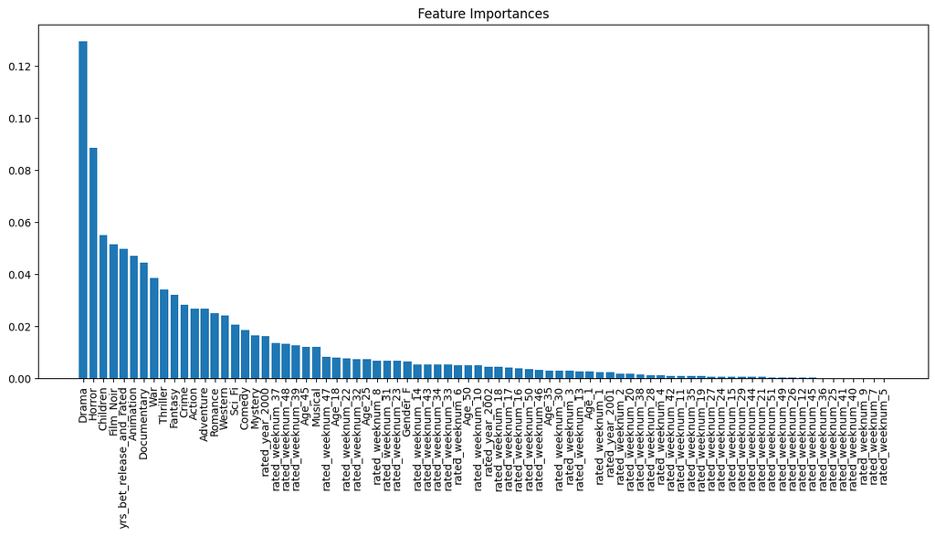

```python
param_dict=pickle.load(open(estimator_pkl,'rb'))
estimator=param_dict['best_estimator']

y_pred_test = estimator.predict(xtest)

mse, rmse, mape = accuracy_checks(ytest, y_pred_test)


if hasattr(estimator, 'feature_importances_'):
    importances = estimator.feature_importances_
    print("Feature importances:")
elif hasattr(estimator, 'coef_'):
    importances = estimator.coef_
    print("Model coefficients:")
    print(importances)
else:
    print("The best regressor does not provide feature importances or coefficients.")

# Optional: visualize feature importances if available
if 'importances' in locals():
    feature_names = xtrain.columns if hasattr(xtrain, 'columns') else np.arange(xtrain.shape[1])
    sorted_indices = np.argsort(importances)[::-1]

    plt.figure(figsize=(15, 6))
    plt.bar(range(len(importances)), importances[sorted_indices], align='center')
    plt.xticks(range(len(importances)), feature_names[sorted_indices], rotation=90)
    plt.title('Feature Importances')
    plt.show()
```

35% MAPE with XGBoost

```python
##However, XGBoost cant capture latent patterns
##doesnt account for movies and users that don't cooccur
```